# lab4

## Team Members

- Name 1: Alex Chan
- Name 2: Max Link
- Name 3: Pablo Arroliga

## Load, Split, and Balance

[.5 points] (1) Load the data into memory and save it to a pandas data frame. Do not normalize or one-hot encode any of the features until asked to do so later in the rubric. (2) Remove any observations that have missing data. (3) Encode any string data as integers for now. (4) You have the option of keeping the "country" variable or removing it. Be sure to discuss why you decided to keep/remove this variable.

```python
import pandas as pd

#reading files from google drive. Reading the mazes folder
from google.colab import drive
drive.mount('/content/drive')

#access mazes content in drive
file_path = '/content/drive/My Drive/census_tract.csv'

# reading data from the google drive file path
data = pd.read_csv(file_path)
df = pd.DataFrame(data)

pd.set_option('display.max_columns', None)
df.head(10)
```

|  | TractId | State | County | TotalPop | Men | Women | Hispanic | White | Black | Native | Asian | Pacific | VotingAgeCitizen | Income | IncomeErr | IncomePerCap | IncomePerCapErr | Poverty | ChildPoverty | Professional | Service | Office | Construction | Production | Drive | Carpool | Transit | Walk | OtherTransp | … |
| --- | --- | --- | --- | --- | --- | --- | --- | --- | --- | --- | --- | --- | --- | --- | --- | --- | --- | --- | --- | --- | --- | --- | --- | --- | --- | --- | --- | --- | --- | --- |
| 0 | 1001020100 | Alabama | Autauga County | 1845 | 899 | 946 | 2.4 | 86.3 | 5.2 | 0.0 | 1.2 | 0.0 | 1407 | 67826.0 | 14560.0 | 33018.0 | 6294.0 | 10.7 | 20.8 | 38.5 | 15.6 | 22.8 | 10.8 | 12.4 | 94.2 | 3.3 | 0.0 | 0.5 | 0.0 | … |
| 1 | 1001020200 | Alabama | Autauga County | 2172 | 1167 | 1005 | 1.1 | 41.6 | 54.5 | 0.0 | 1.0 | 0.0 | 1652 | 41287.0 | 3819.0 | 18996.0 | 2453.0 | 22.4 | 35.8 | 30.5 | 24.9 | 22.9 | 6.3 | 15.4 | 90.5 | 9.1 | 0.0 | 0.0 | 0.5 | … |
| 2 | 1001020300 | Alabama | Autauga County | 3385 | 1533 | 1852 | 8.0 | 61.4 | 26.5 | 0.6 | 0.7 | 0.4 | 2480 | 46806.0 | 9496.0 | 21236.0 | 2562.0 | 14.7 | 21.1 | 27.9 | 19.4 | 33.3 | 9.9 | 9.6 | 88.3 | 8.4 | 0.0 | 1.0 | 0.8 | … |
| 3 | 1001020400 | Alabama | Autauga County | 4267 | 2001 | 2266 | 9.6 | 80.3 | 7.1 | 0.5 | 0.2 | 0.0 | 3257 | 55895.0 | 4369.0 | 28068.0 | 3190.0 | 2.3 | 1.7 | 29.0 | 16.6 | 25.8 | 9.1 | 19.5 | 82.3 | 11.2 | 0.0 | 1.5 | 2.9 | … |
| 4 | 1001020500 | Alabama | Autauga County | 9965 | 5054 | 4911 | 0.9 | 77.5 | 16.4 | 0.0 | 3.1 | 0.0 | 7229 | 68143.0 | 14424.0 | 36905.0 | 10706.0 | 12.2 | 17.9 | 48.8 | 13.8 | 20.5 | 3.5 | 13.4 | 86.9 | 11.2 | 0.0 | 0.8 | 0.3 | … |
| 5 | 1001020600 | Alabama | Autauga County | 3620 | 1765 | 1855 | 3.0 | 70.7 | 25.1 | 0.0 | 0.0 | 0.0 | 2687 | 44549.0 | 16126.0 | 27038.0 | 4427.0 | 13.6 | 20.2 | 25.2 | 24.6 | 29.0 | 8.1 | 13.1 | 83.0 | 4.8 | 0.0 | 0.7 | 3.5 | … |
| 6 | 1001020700 | Alabama | Autauga County | 3420 | 1459 | 1961 | 4.0 | 78.0 | 13.7 | 0.6 | 0.0 | 0.0 | 2538 | 41250.0 | 16811.0 | 19028.0 | 2587.0 | 27.0 | 27.7 | 25.4 | 35.0 | 21.6 | 5.6 | 12.4 | 89.0 | 11.0 | 0.0 | 0.0 | 0.0 | … |
| 7 | 1001020801 | Alabama | Autauga County | 2913 | 1495 | 1418 | 4.2 | 86.3 | 7.1 | 1.5 | 0.0 | 0.0 | 2163 | 80089.0 | 13397.0 | 36631.0 | 5174.0 | 12.0 | 25.1 | 46.0 | 9.1 | 30.6 | 8.3 | 6.0 | 89.5 | 4.6 | 0.0 | 0.0 | 0.7 | … |
| 8 | 1001020802 | Alabama | Autauga County | 11333 | 5488 | 5845 | 1.4 | 81.8 | 15.3 | 0.0 | 1.0 | 0.0 | 8248 | 64439.0 | 8677.0 | 26621.0 | 2187.0 | 14.7 | 21.8 | 36.8 | 20.2 | 19.6 | 9.3 | 14.0 | 89.1 | 8.7 | 0.0 | 0.0 | 0.0 | … |
| 9 | 1001020900 | Alabama | Autauga County | 6167 | 3111 | 3056 | 1.0 | 86.2 | 9.7 | 0.8 | 0.3 | 0.0 | 4710 | 49469.0 | 15517.0 | 26726.0 | 3839.0 | 9.4 | 13.2 | 32.3 | 12.7 | 20.1 | 6.4 | 28.6 | 77.2 | 11.9 | 0.0 | 0.0 | 5.0 | … |

```python
df.info()
```

```
<class 'pandas.core.frame.DataFrame'>
RangeIndex: 74001 entries, 0 to 74000
Data columns (total 37 columns):
 #   Column            Non-Null Count  Dtype
---  ------            --------------  -----
 0   TractId           74001 non-null  int64
 1   State             74001 non-null  object
 2   County            74001 non-null  object
 3   TotalPop          74001 non-null  int64
 4   Men               74001 non-null  int64
 5   Women             74001 non-null  int64
 6   Hispanic          73305 non-null  float64
 7   White             73305 non-null  float64
 8   Black             73305 non-null  float64
 9   Native            73305 non-null  float64
```

[output cut: 29 more lines]

```python
df = df.dropna()

df.info()
```

```
<class 'pandas.core.frame.DataFrame'>
Int64Index: 72718 entries, 0 to 74000
Data columns (total 37 columns):
 #   Column            Non-Null Count  Dtype
---  ------            --------------  -----
 0   TractId           72718 non-null  int64
 1   State             72718 non-null  object
 2   County            72718 non-null  object
 3   TotalPop          72718 non-null  int64
 4   Men               72718 non-null  int64
 5   Women             72718 non-null  int64
 6   Hispanic          72718 non-null  float64
 7   White             72718 non-null  float64
 8   Black             72718 non-null  float64
 9   Native            72718 non-null  float64
```

[output cut: 29 more lines]

```python
# generate descriptive statistics of the dataframe
# shows central tendency, dispersion, and distribution of the data through various statistics like min, mean, max, etc.
# excludes NaN values
df.describe()
```

|  | TractId | TotalPop | Men | Women | Hispanic | White | Black | Native | Asian | Pacific | VotingAgeCitizen | Income | IncomeErr | IncomePerCap | IncomePerCapErr | Poverty | ChildPoverty | Professional | Service | Office | Construction | Production | Drive | Carpool | Transit | Walk | OtherTransp | WorkAtHome | MeanCommute | … |
| --- | --- | --- | --- | --- | --- | --- | --- | --- | --- | --- | --- | --- | --- | --- | --- | --- | --- | --- | --- | --- | --- | --- | --- | --- | --- | --- | --- | --- | --- | --- |
| count | 7.271800e+04 | 72718.000000 | 72718.000000 | 72718.000000 | 72718.000000 | 72718.000000 | 72718.000000 | 72718.000000 | 72718.000000 | 72718.000000 | 72718.000000 | 72718.000000 | 72718.000000 | 72718.000000 | 72718.000000 | 72718.000000 | 72718.000000 | 72718.000000 | 72718.000000 | 72718.000000 | 72718.000000 | 72718.000000 | 72718.000000 | 72718.000000 | 72718.000000 | 72718.000000 | 72718.000000 | 72718.000000 | 72718.000000 | … |
| mean | 2.837292e+10 | 4443.485121 | 2184.362647 | 2259.122473 | 17.282951 | 61.337143 | 13.254417 | 0.727776 | 4.752459 | 0.146082 | 3141.161982 | 61119.999326 | 9690.325642 | 30666.653222 | 4249.725969 | 16.046724 | 21.148476 | 35.553813 | 18.847948 | 23.413165 | 9.263044 | 12.922312 | 75.880830 | 9.324557 | 5.370585 | 2.925778 | 1.886076 | 4.612646 | 26.080334 | … |
| std | 1.644198e+10 | 2190.183318 | 1099.954423 | 1124.604806 | 23.084428 | 30.628031 | 21.581269 | 4.505791 | 8.995573 | 1.015198 | 1512.610257 | 30511.062580 | 6119.407315 | 15844.127467 | 2991.009809 | 12.428643 | 18.572714 | 15.038790 | 7.969609 | 5.591354 | 5.943849 | 7.592511 | 14.960499 | 5.107717 | 11.626060 | 5.260623 | 2.485812 | 3.770733 | 7.095680 | … |
| min | 1.001020e+09 | 58.000000 | 26.000000 | 27.000000 | 0.000000 | 0.000000 | 0.000000 | 0.000000 | 0.000000 | 0.000000 | 40.000000 | 2692.000000 | 728.000000 | 1631.000000 | 351.000000 | 0.000000 | 0.000000 | 0.000000 | 0.000000 | 0.000000 | 0.000000 | 0.000000 | 0.000000 | 0.000000 | 0.000000 | 0.000000 | 0.000000 | 0.000000 | 4.200000 | … |
| 25% | 1.304703e+10 | 2958.000000 | 1440.000000 | 1494.000000 | 2.600000 | 38.100000 | 0.800000 | 0.000000 | 0.200000 | 0.000000 | 2096.000000 | 40380.000000 | 5737.000000 | 20624.000000 | 2508.000000 | 6.900000 | 6.200000 | 24.700000 | 13.300000 | 19.700000 | 5.000000 | 7.200000 | 72.400000 | 5.800000 | 0.000000 | 0.400000 | 0.400000 | 2.000000 | 21.100000 | … |
| 50% | 2.804700e+10 | 4137.000000 | 2024.000000 | 2102.000000 | 7.400000 | 70.500000 | 3.800000 | 0.000000 | 1.500000 | 0.000000 | 2926.000000 | 54413.000000 | 8268.000000 | 27249.000000 | 3404.000000 | 12.600000 | 16.300000 | 33.300000 | 17.700000 | 23.200000 | 8.400000 | 11.800000 | 79.900000 | 8.500000 | 1.000000 | 1.400000 | 1.200000 | 3.800000 | 25.400000 | … |
| 75% | 4.200341e+10 | 5532.750000 | 2719.000000 | 2817.000000 | 21.100000 | 87.700000 | 14.500000 | 0.400000 | 5.000000 | 0.000000 | 3923.000000 | 74688.000000 | 11909.000000 | 36413.000000 | 4959.000000 | 21.800000 | 31.600000 | 44.800000 | 23.200000 | 26.900000 | 12.500000 | 17.500000 | 84.900000 | 11.900000 | 4.600000 | 3.300000 | 2.500000 | 6.300000 | 30.300000 | … |
| max | 7.215375e+10 | 65528.000000 | 32266.000000 | 33262.000000 | 100.000000 | 100.000000 | 100.000000 | 99.400000 | 91.400000 | 71.900000 | 39389.000000 | 249750.000000 | 153365.000000 | 220253.000000 | 84414.000000 | 100.000000 | 100.000000 | 92.200000 | 70.900000 | 72.300000 | 68.100000 | 60.500000 | 100.000000 | 64.000000 | 90.800000 | 77.700000 | 53.400000 | 82.800000 | 73.900000 | … |

```python
# encode any string data as integers
from sklearn.preprocessing import LabelEncoder

le = LabelEncoder()

df['State'] = le.fit_transform(df['State'])
df['County'] = le.fit_transform(df['County'])

# drop TractID and County, axis=1 means drop the TractID & County Columns specifically
df = df.drop(['TractId', 'County'], axis=1)

df.head(10)
```

|  | State | TotalPop | Men | Women | Hispanic | White | Black | Native | Asian | Pacific | VotingAgeCitizen | Income | IncomeErr | IncomePerCap | IncomePerCapErr | Poverty | ChildPoverty | Professional | Service | Office | Construction | Production | Drive | Carpool | Transit | Walk | OtherTransp | WorkAtHome | MeanCommute | … |
| --- | --- | --- | --- | --- | --- | --- | --- | --- | --- | --- | --- | --- | --- | --- | --- | --- | --- | --- | --- | --- | --- | --- | --- | --- | --- | --- | --- | --- | --- | --- |
| 0 | 0 | 1845 | 899 | 946 | 2.4 | 86.3 | 5.2 | 0.0 | 1.2 | 0.0 | 1407 | 67826.0 | 14560.0 | 33018.0 | 6294.0 | 10.7 | 20.8 | 38.5 | 15.6 | 22.8 | 10.8 | 12.4 | 94.2 | 3.3 | 0.0 | 0.5 | 0.0 | 2.1 | 24.5 | … |
| 1 | 0 | 2172 | 1167 | 1005 | 1.1 | 41.6 | 54.5 | 0.0 | 1.0 | 0.0 | 1652 | 41287.0 | 3819.0 | 18996.0 | 2453.0 | 22.4 | 35.8 | 30.5 | 24.9 | 22.9 | 6.3 | 15.4 | 90.5 | 9.1 | 0.0 | 0.0 | 0.5 | 0.0 | 22.2 | … |
| 2 | 0 | 3385 | 1533 | 1852 | 8.0 | 61.4 | 26.5 | 0.6 | 0.7 | 0.4 | 2480 | 46806.0 | 9496.0 | 21236.0 | 2562.0 | 14.7 | 21.1 | 27.9 | 19.4 | 33.3 | 9.9 | 9.6 | 88.3 | 8.4 | 0.0 | 1.0 | 0.8 | 1.5 | 23.1 | … |
| 3 | 0 | 4267 | 2001 | 2266 | 9.6 | 80.3 | 7.1 | 0.5 | 0.2 | 0.0 | 3257 | 55895.0 | 4369.0 | 28068.0 | 3190.0 | 2.3 | 1.7 | 29.0 | 16.6 | 25.8 | 9.1 | 19.5 | 82.3 | 11.2 | 0.0 | 1.5 | 2.9 | 2.1 | 25.9 | … |
| 4 | 0 | 9965 | 5054 | 4911 | 0.9 | 77.5 | 16.4 | 0.0 | 3.1 | 0.0 | 7229 | 68143.0 | 14424.0 | 36905.0 | 10706.0 | 12.2 | 17.9 | 48.8 | 13.8 | 20.5 | 3.5 | 13.4 | 86.9 | 11.2 | 0.0 | 0.8 | 0.3 | 0.7 | 21.0 | … |
| 5 | 0 | 3620 | 1765 | 1855 | 3.0 | 70.7 | 25.1 | 0.0 | 0.0 | 0.0 | 2687 | 44549.0 | 16126.0 | 27038.0 | 4427.0 | 13.6 | 20.2 | 25.2 | 24.6 | 29.0 | 8.1 | 13.1 | 83.0 | 4.8 | 0.0 | 0.7 | 3.5 | 8.0 | 21.1 | … |
| 6 | 0 | 3420 | 1459 | 1961 | 4.0 | 78.0 | 13.7 | 0.6 | 0.0 | 0.0 | 2538 | 41250.0 | 16811.0 | 19028.0 | 2587.0 | 27.0 | 27.7 | 25.4 | 35.0 | 21.6 | 5.6 | 12.4 | 89.0 | 11.0 | 0.0 | 0.0 | 0.0 | 0.0 | 16.4 | … |
| 7 | 0 | 2913 | 1495 | 1418 | 4.2 | 86.3 | 7.1 | 1.5 | 0.0 | 0.0 | 2163 | 80089.0 | 13397.0 | 36631.0 | 5174.0 | 12.0 | 25.1 | 46.0 | 9.1 | 30.6 | 8.3 | 6.0 | 89.5 | 4.6 | 0.0 | 0.0 | 0.7 | 5.2 | 24.6 | … |
| 8 | 0 | 11333 | 5488 | 5845 | 1.4 | 81.8 | 15.3 | 0.0 | 1.0 | 0.0 | 8248 | 64439.0 | 8677.0 | 26621.0 | 2187.0 | 14.7 | 21.8 | 36.8 | 20.2 | 19.6 | 9.3 | 14.0 | 89.1 | 8.7 | 0.0 | 0.0 | 0.0 | 2.2 | 27.4 | … |
| 9 | 0 | 6167 | 3111 | 3056 | 1.0 | 86.2 | 9.7 | 0.8 | 0.3 | 0.0 | 4710 | 49469.0 | 15517.0 | 26726.0 | 3839.0 | 9.4 | 13.2 | 32.3 | 12.7 | 20.1 | 6.4 | 28.6 | 77.2 | 11.9 | 0.0 | 0.0 | 5.0 | 5.9 | 35.6 | … |

We are removing County because it is an extra level of complexity that would only slow down our model. There are way too many counties to one hot encode, and including County data would only introduce the curse of dimensionality and hurt our model's ability to learn effectively. We are interested in the data at a higher level than County, so we can safely remove County to avoid these issues.

There are only 52 states, so states can be kept without being too computationally intensive.

The next two requirements will need to be completed together as they might depend on one another:

[.5 points] Balance the dataset so that about the same number of instances are within each class. Choose a method for balancing the dataset and explain your reasoning for selecting this method. One option is to choose quantization thresholds for the "ChildPoverty" variable that equally divide the data into four classes. Should balancing of the dataset be done for both the training and testing set? Explain

[.5 points] Assume you are equally interested in the classification performance for each class in the dataset. Split the dataset into 80% for training and 20% for testing. There is no need to split the data multiple times for this lab.

Note: You will need to one hot encode the target, but do not one hot encode the categorical data until insturcted to do so in the lab.

```python
# method for balancing the dataset: Quantile Based Discretization with the pd.qcut function.
# performing quantile based discretization on the ChildPoverty Column
# pd.qcut divides the continuous data in the ChildPoverty column into 4 quantiles: Low, Medium, High, Extreme
# This balances the data by dividing it into 4 groups
# each value in the ChildPoverty column is replaced by a categorical label indicating its quantile
# This method sorts the ChildPoverty column data into 4 discrete classes based on data distribution
# This new data is stored in a new column called 'ChildPovertyClass'
# Code from https://pbpython.com/pandas-qcut-cut.html
df['ChildPovertyClass'] = pd.qcut(df['ChildPoverty'], q=4, labels=['Low', 'Medium', 'High', 'Extreme'])

# Now that we have ChildPovertyClass, remove the original ChildPoverty column from the original dataframe with inplace=True
df.drop(['ChildPoverty'], axis=1, inplace=True)

df.head(10)
```

|  | State | TotalPop | Men | Women | Hispanic | White | Black | Native | Asian | Pacific | VotingAgeCitizen | Income | IncomeErr | IncomePerCap | IncomePerCapErr | Poverty | Professional | Service | Office | Construction | Production | Drive | Carpool | Transit | Walk | OtherTransp | WorkAtHome | MeanCommute | Employed | … |
| --- | --- | --- | --- | --- | --- | --- | --- | --- | --- | --- | --- | --- | --- | --- | --- | --- | --- | --- | --- | --- | --- | --- | --- | --- | --- | --- | --- | --- | --- | --- |
| 0 | 0 | 1845 | 899 | 946 | 2.4 | 86.3 | 5.2 | 0.0 | 1.2 | 0.0 | 1407 | 67826.0 | 14560.0 | 33018.0 | 6294.0 | 10.7 | 38.5 | 15.6 | 22.8 | 10.8 | 12.4 | 94.2 | 3.3 | 0.0 | 0.5 | 0.0 | 2.1 | 24.5 | 881 | … |
| 1 | 0 | 2172 | 1167 | 1005 | 1.1 | 41.6 | 54.5 | 0.0 | 1.0 | 0.0 | 1652 | 41287.0 | 3819.0 | 18996.0 | 2453.0 | 22.4 | 30.5 | 24.9 | 22.9 | 6.3 | 15.4 | 90.5 | 9.1 | 0.0 | 0.0 | 0.5 | 0.0 | 22.2 | 852 | … |
| 2 | 0 | 3385 | 1533 | 1852 | 8.0 | 61.4 | 26.5 | 0.6 | 0.7 | 0.4 | 2480 | 46806.0 | 9496.0 | 21236.0 | 2562.0 | 14.7 | 27.9 | 19.4 | 33.3 | 9.9 | 9.6 | 88.3 | 8.4 | 0.0 | 1.0 | 0.8 | 1.5 | 23.1 | 1482 | … |
| 3 | 0 | 4267 | 2001 | 2266 | 9.6 | 80.3 | 7.1 | 0.5 | 0.2 | 0.0 | 3257 | 55895.0 | 4369.0 | 28068.0 | 3190.0 | 2.3 | 29.0 | 16.6 | 25.8 | 9.1 | 19.5 | 82.3 | 11.2 | 0.0 | 1.5 | 2.9 | 2.1 | 25.9 | 1849 | … |
| 4 | 0 | 9965 | 5054 | 4911 | 0.9 | 77.5 | 16.4 | 0.0 | 3.1 | 0.0 | 7229 | 68143.0 | 14424.0 | 36905.0 | 10706.0 | 12.2 | 48.8 | 13.8 | 20.5 | 3.5 | 13.4 | 86.9 | 11.2 | 0.0 | 0.8 | 0.3 | 0.7 | 21.0 | 4787 | … |
| 5 | 0 | 3620 | 1765 | 1855 | 3.0 | 70.7 | 25.1 | 0.0 | 0.0 | 0.0 | 2687 | 44549.0 | 16126.0 | 27038.0 | 4427.0 | 13.6 | 25.2 | 24.6 | 29.0 | 8.1 | 13.1 | 83.0 | 4.8 | 0.0 | 0.7 | 3.5 | 8.0 | 21.1 | 1364 | … |
| 6 | 0 | 3420 | 1459 | 1961 | 4.0 | 78.0 | 13.7 | 0.6 | 0.0 | 0.0 | 2538 | 41250.0 | 16811.0 | 19028.0 | 2587.0 | 27.0 | 25.4 | 35.0 | 21.6 | 5.6 | 12.4 | 89.0 | 11.0 | 0.0 | 0.0 | 0.0 | 0.0 | 16.4 | 1418 | … |
| 7 | 0 | 2913 | 1495 | 1418 | 4.2 | 86.3 | 7.1 | 1.5 | 0.0 | 0.0 | 2163 | 80089.0 | 13397.0 | 36631.0 | 5174.0 | 12.0 | 46.0 | 9.1 | 30.6 | 8.3 | 6.0 | 89.5 | 4.6 | 0.0 | 0.0 | 0.7 | 5.2 | 24.6 | 1369 | … |
| 8 | 0 | 11333 | 5488 | 5845 | 1.4 | 81.8 | 15.3 | 0.0 | 1.0 | 0.0 | 8248 | 64439.0 | 8677.0 | 26621.0 | 2187.0 | 14.7 | 36.8 | 20.2 | 19.6 | 9.3 | 14.0 | 89.1 | 8.7 | 0.0 | 0.0 | 0.0 | 2.2 | 27.4 | 4857 | … |
| 9 | 0 | 6167 | 3111 | 3056 | 1.0 | 86.2 | 9.7 | 0.8 | 0.3 | 0.0 | 4710 | 49469.0 | 15517.0 | 26726.0 | 3839.0 | 9.4 | 32.3 | 12.7 | 20.1 | 6.4 | 28.6 | 77.2 | 11.9 | 0.0 | 0.0 | 5.0 | 5.9 | 35.6 | 2781 | … |

```python
# encoding the 'ChildPovertyClass' columns strings: low, medium, high, extreme into integers
# 0: low, 1: medium, 2: high, 3: extreme
le = LabelEncoder()
df['ChildPovertyClass'] = le.fit_transform(df['ChildPovertyClass'])

df.head(10)
```

|  | State | TotalPop | Men | Women | Hispanic | White | Black | Native | Asian | Pacific | VotingAgeCitizen | Income | IncomeErr | IncomePerCap | IncomePerCapErr | Poverty | Professional | Service | Office | Construction | Production | Drive | Carpool | Transit | Walk | OtherTransp | WorkAtHome | MeanCommute | Employed | … |
| --- | --- | --- | --- | --- | --- | --- | --- | --- | --- | --- | --- | --- | --- | --- | --- | --- | --- | --- | --- | --- | --- | --- | --- | --- | --- | --- | --- | --- | --- | --- |
| 0 | 0 | 1845 | 899 | 946 | 2.4 | 86.3 | 5.2 | 0.0 | 1.2 | 0.0 | 1407 | 67826.0 | 14560.0 | 33018.0 | 6294.0 | 10.7 | 38.5 | 15.6 | 22.8 | 10.8 | 12.4 | 94.2 | 3.3 | 0.0 | 0.5 | 0.0 | 2.1 | 24.5 | 881 | … |
| 1 | 0 | 2172 | 1167 | 1005 | 1.1 | 41.6 | 54.5 | 0.0 | 1.0 | 0.0 | 1652 | 41287.0 | 3819.0 | 18996.0 | 2453.0 | 22.4 | 30.5 | 24.9 | 22.9 | 6.3 | 15.4 | 90.5 | 9.1 | 0.0 | 0.0 | 0.5 | 0.0 | 22.2 | 852 | … |
| 2 | 0 | 3385 | 1533 | 1852 | 8.0 | 61.4 | 26.5 | 0.6 | 0.7 | 0.4 | 2480 | 46806.0 | 9496.0 | 21236.0 | 2562.0 | 14.7 | 27.9 | 19.4 | 33.3 | 9.9 | 9.6 | 88.3 | 8.4 | 0.0 | 1.0 | 0.8 | 1.5 | 23.1 | 1482 | … |
| 3 | 0 | 4267 | 2001 | 2266 | 9.6 | 80.3 | 7.1 | 0.5 | 0.2 | 0.0 | 3257 | 55895.0 | 4369.0 | 28068.0 | 3190.0 | 2.3 | 29.0 | 16.6 | 25.8 | 9.1 | 19.5 | 82.3 | 11.2 | 0.0 | 1.5 | 2.9 | 2.1 | 25.9 | 1849 | … |
| 4 | 0 | 9965 | 5054 | 4911 | 0.9 | 77.5 | 16.4 | 0.0 | 3.1 | 0.0 | 7229 | 68143.0 | 14424.0 | 36905.0 | 10706.0 | 12.2 | 48.8 | 13.8 | 20.5 | 3.5 | 13.4 | 86.9 | 11.2 | 0.0 | 0.8 | 0.3 | 0.7 | 21.0 | 4787 | … |
| 5 | 0 | 3620 | 1765 | 1855 | 3.0 | 70.7 | 25.1 | 0.0 | 0.0 | 0.0 | 2687 | 44549.0 | 16126.0 | 27038.0 | 4427.0 | 13.6 | 25.2 | 24.6 | 29.0 | 8.1 | 13.1 | 83.0 | 4.8 | 0.0 | 0.7 | 3.5 | 8.0 | 21.1 | 1364 | … |
| 6 | 0 | 3420 | 1459 | 1961 | 4.0 | 78.0 | 13.7 | 0.6 | 0.0 | 0.0 | 2538 | 41250.0 | 16811.0 | 19028.0 | 2587.0 | 27.0 | 25.4 | 35.0 | 21.6 | 5.6 | 12.4 | 89.0 | 11.0 | 0.0 | 0.0 | 0.0 | 0.0 | 16.4 | 1418 | … |
| 7 | 0 | 2913 | 1495 | 1418 | 4.2 | 86.3 | 7.1 | 1.5 | 0.0 | 0.0 | 2163 | 80089.0 | 13397.0 | 36631.0 | 5174.0 | 12.0 | 46.0 | 9.1 | 30.6 | 8.3 | 6.0 | 89.5 | 4.6 | 0.0 | 0.0 | 0.7 | 5.2 | 24.6 | 1369 | … |
| 8 | 0 | 11333 | 5488 | 5845 | 1.4 | 81.8 | 15.3 | 0.0 | 1.0 | 0.0 | 8248 | 64439.0 | 8677.0 | 26621.0 | 2187.0 | 14.7 | 36.8 | 20.2 | 19.6 | 9.3 | 14.0 | 89.1 | 8.7 | 0.0 | 0.0 | 0.0 | 2.2 | 27.4 | 4857 | … |
| 9 | 0 | 6167 | 3111 | 3056 | 1.0 | 86.2 | 9.7 | 0.8 | 0.3 | 0.0 | 4710 | 49469.0 | 15517.0 | 26726.0 | 3839.0 | 9.4 | 32.3 | 12.7 | 20.1 | 6.4 | 28.6 | 77.2 | 11.9 | 0.0 | 0.0 | 5.0 | 5.9 | 35.6 | 2781 | … |

```python
# data training/testing split preparation, making the X and y variables

# import numpy to make a numpy array
import numpy as np
# converting the df columns to a numpy array, X, and assigning the df columns to the features variable X
# here, the 'ChildPovertyClass' column is dropped from the df before the df is assigned
# this is so that 'ChildPovertyClass' does not get assigned to the features variable
# the features variable should only hold the independent variables that affect the 'ChildPovertyClass' variable
# the 'ChildPovertyClass' is our target variable, and you do not include your target variable in your X
X = np.array(df.drop(['ChildPovertyClass'], axis=1))

# assigning the ChildPovertyClass into the samples variable y
# the sample variable y is our target variable, or dependent variable
# this is the variable that we aim to predict or classify
# y becomes a standalone series, not a column in the dataframe
y = df['ChildPovertyClass']

# X is a numpy array, X.shape returns the rows and columns of the array
# rows (samples), columns (features)
# This extracts the dimensions of X
n_samples, n_features = X.shape

# printing the dimensions of X as samples and features to verify the dimensions of the dataset
print("n_samples: {}".format(n_samples))
print("n_features: {}".format(n_features))
```

```
n_samples: 72718
n_features: 34
```

```python
# splitting the data
from sklearn.model_selection import train_test_split

# split ratio: 80% training, 20% testing
# y_train and y_test are pandas series, but they inherit the original dataframes indexes and these indexes get unordered from the splitting
# the train_test_split function returns two numpy arrays (from X input) & two series (from y input) into their appropriate variables
# X_train, X_test are numpy arrays
# y_train, y_test are series (one dimensional labelled array)
X_train, X_test, y_train, y_test = train_test_split(X, y, test_size=0.2, train_size=0.8,
                                                    stratify=df['ChildPovertyClass']) # stratify is used to ensure the training & testing sets have about the same amount of each target class (low, medium, high, extreme) as the original dataset

# reset the y_train and y_test series indexes here so that they are not scrambled
# drop=True to remove the original unordered columns from the series, so that the y_train and y_test series do not have the old unordered series attached
y_train = y_train.reset_index(drop=True) # make the index of the y_train sequential (0, 1, 2...)
y_test = y_test.reset_index(drop=True) # make the index of the y_test sequential (0, 1, 2...)

# the X_train and X_test are numpy arrays (not series)
# the X_train and X_test values are inputted into the model & the order of their values are usually not important, so we do not have to reindex those
```

```python
from collections import Counter # count the amount of unique values in y_train and y_test

# counts is a dictionary, where it holds the y_train series values
# the Counter gets the classes from y_train & it counts the occurences of each class (0, 1, 2, 3)
counts = Counter(y_train) # make a counter object. The counter object counts an item based on its hash value. It counts duplicates.
print('Y-Train:')
# value is the class from the dictionary
# count is the amount of unique hashable items from the dictionary
for value, count in counts.items(): # iterate through the integer classes (0:low, 1: medium, 2: high, 3: extreme). Printed as integers.
    print(f"\t{value} occurs {count} times") # printing the amounts for each class.

# repeat this counter process for y_test
counts = Counter(y_test)
print('Y-Test:')
for value, count in counts.items():
    print(f"\t{value} occurs {count} times")
```

```
Y-Train:
	1 occurs 14518 times
	2 occurs 14583 times
	0 occurs 14536 times
	3 occurs 14537 times
Y-Test:
	0 occurs 3634 times
	2 occurs 3646 times
	1 occurs 3630 times
	3 occurs 3634 times
```

We decided to use quantile-based discretization to balance our ChildPoverty column. We used quantile-based discretization to turn our continous ChildPoverty data into categorical data by throwing it into as many equal bins as possible [0, 1, 2, 3]. We paired this with stratifying our data when splitting it for training and testing data. Combining quantile-based discretization with stratifying ensures that the model has a balanced view of the data, making the model generalizable when dealing with unseen data.

The testing set is not reflective of the real world if it is balanced. If the testing set is balanced along with the training set, then the model's performance may be overly optimistic, so balancing both the training and testing set is not the best idea. In an ideal scenario, only the training set would be balanced, and the testing set would not be balanced.

Having said this, scikit-learn's train_test_split & stratify keywords force us to balance both the training and testing sets, so they will both be balanced for this lab.

## Pre-processing and Initial Modeling

You will be using a two layer perceptron from class for the next few parts of the rubric. There are several versions of the two layer perceptron covered in class, with example code. When selecting an example two layer network from class be sure that you use: (1) vectorized gradient computation, (2) mini-batching, (3) cross entropy loss, and (4) proper Glorot initialization, at a minimum. There is no need to use momentum or learning rate reduction (assuming you choose a sufficiently small learning rate). It is recommended to use sigmoids throughout the network, but not required.

```python
# Example adapted from https://github.com/rasbt/python-machine-learning-book/blob/master/code/ch12/ch12.ipynb
# Original Author: Sebastian Raschka

# This is the optional book we use in the course, excellent intuitions and straightforward programming examples
# please note, however, that this code has been manipulated to reflect our assumptions and notation.
import numpy as np
from scipy.special import expit
import pandas as pd
import sys

# start with a simple base classifier, which can't be fit or predicted
# it only has internal classes to be used by classes that will subclass it
class TwoLayerPerceptronBase(object): # since this is a base class, we will extend it with subclasses later for added functionality
# this constructor method initializes the neural network with specified parameters
# n_hidden is the # of neurons in the hidden layer
# C: regularization strength for L2 Regularization
# epochs is the number of iterations
# eta is the learning rate
# random_state is a seed for random number generation. Set to none to produce a different set of random numbers each run.
# random_state is passed into the np.random.seed function as a parameter to control the random numbers that are generated by numpy
    def __init__(self, n_hidden=30,
                 C=0.0, epochs=500, eta=0.001, random_state=None):
        np.random.seed(random_state)
        self.n_hidden = n_hidden
        self.l2_C = C
        self.epochs = epochs
        self.eta = eta

# utility methods -- below

    # one hot encoding is done here
    @staticmethod
    def _encode_labels(y): # encode_labels encodes categorical labels into a one_hot representation using pandas get_dummies function
    # this one hot encoding is useful for multi-class classification
        """Encode labels into one-hot representation"""
        onehot = pd.get_dummies(y).values.T

        return onehot

    # initializes weights for the network with small random numbers. Here we are calculating two weights (w1 and w2)
    # we follow a uniform distribution principle here between -1.0 and 1.0
    # this implementation almost follows the Glorot principle, but we do not have fan-in and fan-out
    # without fan-in and fan-out, we are not scaling the uniform distribution to include the previous and next layers
    # the glorot principle includes the previous and next layers to ensure that the variance of activation remains controlled across layers
    def _initialize_weights(self):
        """Initialize weights with small random numbers."""
        # calculate the total number of elements needed in the weight matrix, w1
        # w1 connects the input layer to the hidden layer
        # self.n_features is the # features given to the neural network. The +1 accounts for the bias that will be added later. This helps the model fit the data better.
        # self.n_hidden are the number of hidden neurons
        # the hidden neurons are multiplied by the features to give a scalar value for W1_num_elems
        # W1_num_elems is a scalar (single value) that represents the # of elements needed between the input layer (including bias) & hidden layer
        W1_num_elems = (self.n_features_ + 1)*self.n_hidden
        # initialize the W1 variable as a one-dimensional numpy array by sampling random values between -1.0 and 1.0 inclusive.
        # the size tells the function how many random values to generate
        # the size is set to W1_num_elems because W1_num_elems is the # of elements needed between the input layer (including bias) & hidden layer
        # the weights are initially set to these small values (values between -1.0 and 1.0 inclusive) to allow the neural network to break symmetry
        # breaking symmetry allows the Neural Network to learn different features during training
        # W1 is initialized to a one-dimensional numpy array with W1_num_elems elements
        W1 = np.random.uniform(-1.0, 1.0,size=W1_num_elems)
        # reshape the numpy array into a two dimensional matrix
        # this W1 matrix has self.n_hidden rows
        # self.n_features_ + 1 columns where +1 is the bias
        # feedforward neural networks assign hidden neurons on the row and (features + bias) on the columns so that the matrix multiplication of input data and weights work properly
        # the matrix must take on this form to accurately represent the connection between each input feature (with the bias) and each neuron in the hidden layer
        W1 = W1.reshape(self.n_hidden, self.n_features_ + 1) # reshape to be W

        # do the same as what was done for W1 on W2
        # W2 connects the hidden layer to the output layer, so there are no features inputted into the scalar initialization
        W2_num_elems = (self.n_hidden + 1)*self.n_output_
        W2 = np.random.uniform(-1.0, 1.0, size=W2_num_elems)
        W2 = W2.reshape(self.n_output_, self.n_hidden + 1)

        return W1, W2 # return both weight matrices (two dimensional arrays)
    # calculate the sigmoid activation function using expit from scipy
    # the sigmoid activation function maps any real valued numbers in a range between 0 and 1. Great for probabilities!
    # given an input Z (a single number, a list, or a numpy array) expit computes the sigmoid function for each element in Z
    # expit is numerically stable, which means that it can handle big Z values and small Z values without experiencing overflow or underflow
    # overflow: A number too big the computer cannot store it
    # underflow: A number so close to zero that it is rounded down to zero (usually a very large negative number). Cause division by zero & other errors
    # by avoiding underflow and overflow, the sigmoid functions are very accurate for each element of Z
    # our Z is (input + weights + bias term).
    # If X is the input features after adding bias, then Z1 = W1 * X
    # Apply the sigmoid function to Z1 & get an output from the hidden layer called A2
    # Z2 = W2 * A2
    @staticmethod
    def _sigmoid(z):
        """Use scipy.special.expit to avoid overflow"""
        # Sigmoid activation formula: 1.0 / (1.0 + np.exp(-z))
        return expit(z) # return the activation values as a vector or matrix depending on the layer's dimensionality, to be fed through again
```

```python
    # adds a column or row of ones to the input matrix so that bias is included in calculations
    @staticmethod
    def _add_bias_unit(X, how='column'):
        """Add bias unit (column or row of 1s) to array at index 0"""
        if how == 'column': # adds a bias term to each row of the input matrix when set to column. Column is how the bias terms are stacked.
            ones = np.ones((X.shape[0], 1)) # generates an array filled with ones. X.shape[0] is the rows, 1 is the columns
            # function horizontally stacks arrays in a sequence. takes a tuple of arrays as input, & stacks them horizontally (column-wise) to make one array
            # the array of ones is added as the first column of X
            X_new = np.hstack((ones, X))
        elif how == 'row': # adds a bias term to each column of the input matrix when set to row. Row is how the bias terms are stacked.
            ones = np.ones((1, X.shape[1]))
            # function vertically stacks arrays in a sequence. takes a tuple of arrays as input, & stacks them vertically (row-wise) to make one array
            # the array of ones is added as the first row of X
            X_new = np.vstack((ones, X))
        return X_new # return the new X numpy array that accounts for bias
    # computes L2 regularization cost for the weighted matrices
    # excludes the bias terms
    # the L2 regularization is technique to prevent overfitting by penalizing large weights
    # L2 regularization is added to the cost function, and shrinks large weights towards zero, but does not make them exactly zero
    def _L2_reg(self, lambda_, W1, W2):
        """Compute L2-regularization cost"""
        # only compute for non-bias terms
        # lambda_ is the strength of penalization. The higher the lambda means the more you will shrink the weights. Too high a value leads to underfitting
        # W1 and W2 are sliced with the [:, 1:] syntax, which excludes the first column on them both. The first column is the bias terms, so the bias terms are excluded.
        # only the feature weights are penalized
        # the bias terms just adjust threshold activation levels, and do not control impacts of input features. The bias terms are not penalized for this reason.

        # square the weights W1 and W2 with **2 to penalize large weights more than smaller weights. The square of a large # is significantly bigger than the square of a smaller number.
        # compute mean of weights, sum the weights, and take the square root of this sum
        # multiply this square root value by half of the regularization strength (lambda_/2.0)
        return (lambda_/2.0) * np.sqrt(np.mean(W1[:, 1:] ** 2) + np.mean(W2[:, 1:] ** 2))
    # computes the cost function
    # the cost function is the mean squared error between the actual values and the predicted values, with an added term for L2 regularization
    # The total cost of the training process is calculated by this function
    # This function includes the cost from teh networks output error
    # This function includes the regularization term to penalize large weights
    # self = TwoLayerPerceptronBase(object) class, A3 is the predicated values from the neural networks output layer
    # Y_enc is the one hot encoded values that represent the data's actual values
    def _cost(self,A3,Y_enc,W1,W2): # W1 & W2 weight matrices for the two layers of the neural network are passed into the function
        '''Get the objective function value. Calculating the objective function value is the process that optimizes the function during training'''
        # Calculate the mean squared error. Subtract the predicted values from the real values, square the difference, take the mean.
        # Square the values to penalize larger weights compared to smaller weights
        # average these sqyared training differences over all instances of the training data to get the overall mean squared error.
        # mean squared error represents total overall cost or loss associated with the networks predictions
        cost = np.mean((Y_enc-A3)**2)
        # use self to access regularization method defined above
        # l2_C is the penalization strength, W1 and W2 matrices are passed in to have their big weights be penalized (shrunk)
        # regularization combats overfitting
        L2_term = self._L2_reg(self.l2_C, W1, W2)

        # add the cost (mean squared error) to the L2_term (regularization), to get the total cost (cost with weights penalized)
        return cost + L2_term
    # use the feedforward function to pass input data through the network to generate predictions
    def _feedforward(self, X, W1, W2): # take self, The features numpy array X, W1 and W2 matrices
        """Compute feedforward step
        """
        # A1 is a matrix
        A1 = self._add_bias_unit(X, how='column') # A1 uses the add_bias_unit function to add the bias to each row of the weight matrix
        A1 = A1.T # transposes the matrix so that the columns represent instances & the rows represent features (including bias). This is done to align the matrix with multiplication with matrix W1
        Z1 = W1 @ A1 # calculate the linear combination by multiplying two matrices, W1 (weights) & A1 (predicted values). The linear combination is a combination of input values with their corresponding weights, with bias included (see A1 initialization)
        A2 = self._sigmoid(Z1) # calculate the sigmoid function

        # repeat steps done for W1
        A2 = self._add_bias_unit(A2, how='row') # A2 uses the add_bias_unit function to add the bias to each column of the weight matrix
        Z2 = W2 @ A2 # calculate the linear combination for the output layer. Preactivation of the output layer. The preactivations are the state of the networks neurons before applying an activation function like sigmoid.
        A3 = self._sigmoid(Z2) # A3 is the final output of the network
        return A1, Z1, A2, Z2, A3 # return the predicted values (A1 - A3), and the Z values (preactivation of the hidden layer, Z1, and preactivation of the output layer, Z2)
```

```python
    # uses backpropagation algorithm to update the weights in the direction that minimally reduces the cost
    # minimally reduce the cost to ensure stability and precision in the model
    def _get_gradient(self, A1, A2, A3, Z1, Z2, Y_enc, W1, W2): # take the self, A1, A2, A3, Z1, Z2, The one hot encoded true values (Y_enc), The weight matrices (W1 and W2)
        """ Compute gradient step using backpropagation.
        """
        # vectorized backpropagation - vectorized gradient computation
        V2 = -2*(Y_enc-A3)*A3*(1-A3)  # last layer sensitivity
        V1 = A2*(1-A2)*(W2.T @ V2) # back prop the sensitivity

        grad2 = V2 @ A2.T # no bias on final layer
        grad1 = V1[1:,:] @ A1.T # dont back prop sensitivity of bias


        # regularize weights that are not bias terms
        grad1[:, 1:] += W1[:, 1:] * self.l2_C
        grad2[:, 1:] += W2[:, 1:] * self.l2_C

        return grad1, grad2

    # output the predicted class labels for the given input data X
    def predict(self, X):
        """Predict class labels"""
        # pass input data X and weights to the feedforward function
        # ignore the A1, Z1, A2, Z2 that are returned, only want A3 (the final output of the model)
        _, _, _, _, A3 = self._feedforward(X, self.W1, self.W2)
        # each column in the A3 matrix is the models prediction for which class one input example belongs to
        # one column may have:
        # 0.1 -- class 0
        # 0.7 -- class 1
        # 0.1 -- class 2
        # 0.1 -- class 3
        # Here, 0.7 is the highest value, so the column would say that the inputted example belongs to class 1
        # goes through each column of the A3 matrix. Looks at the row of each column, and finds the row that is the highest value.
        # y_pred is an array that is the size of the amount of columns in A3. y_pred holds the classes as integers [1, 0, 2, 3, 1, 1, 2, etc.]
        y_pred = np.argmax(A3, axis=0) # axis=0 specifies columns, so the np.argmax operates column-wise: Chooses a column and looks at the values on its rows.
        return y_pred # returns the array of predicted classes for each input X
```

```python
# now we implement the subclasses to extend the flexibility of our base class

from sklearn.metrics import accuracy_score # accuracy score is used to compute the accuracy of the model's predictions. Used in fit function
# just start with the vectorized version and minibatch
class TLPMiniBatch(TwoLayerPerceptronBase): # this is the minibatch subclass, it inherits the base class
# constructor: Alpha - Momentum coefficient, decrease_const - Factor for decreasing the learning rate over time
# decrease_iter - Determines how often the learning rate decreases,
# shuffle - whether to shuffle the data before each epoch (iteration), in this case true.
# minibatches is the # of minibatches to divide the data into, in this case 1.
# **kwds are additional keyword arguments passed to the superclass initiator
    def __init__(self, alpha=0.0, decrease_const=0.1,
                 decrease_iter = 10, shuffle=True,
                 minibatches=1, **kwds):
        # need to add to the original initializer
        self.alpha = alpha
        self.decrease_const = decrease_const
        self.decrease_iter = decrease_iter
        self.shuffle = shuffle
        self.minibatches = minibatches
        # but keep other keywords
        super().__init__(**kwds) # calls the superclass initiator of the two perceptron base class, allowing it to initialize other common attributes

    # trains the model on the training data X and the labels y
    # optionally accepts validation data XY and a print progress flag to print the progress
    def fit(self, X, y, print_progress=False, XY_test=None):
        """ Learn weights from training data. With mini-batch"""
        X_data, y_data = X.copy(), y.copy() # copy the training data X and labels y to avoid modifying the original data
        Y_enc = self._encode_labels(y) # one hot encoding for classification task

        # init weights and setup matrices - data initialized based on training data and encoded labels
        self.n_features_ = X_data.shape[1] # initialize the number of features
        self.n_output_ = Y_enc.shape[0] # initialize the number of output units
        self.W1, self.W2 = self._initialize_weights() # initialize the weights

        # rhos initailized for momentum calculations - store the previous updates to the weights
        # momentum is used to accelerate the convergence of gradient descent optimization algorithms (see our get_gradient function)
        # momentum helps us avoid getting stuck in local minima in the cost function
        # with momentum, the weight update is a combination of the current gradient + a little of the previous gradient.
        # Like pushing a ball down a hill, ball moves faster over time in one direction
        # again, the rhos represent the previous updates to the weights. The rhos enable us to have momentum.
        # rhos are initialized as zero matrices the same shape as the weights
        rho_W1_prev = np.zeros(self.W1.shape)
        rho_W2_prev = np.zeros(self.W2.shape)

        self.cost_ = [] # initialize a cost array to store the cost over each epoch (iteration)
        self.score_ = [] # initialize a score array to store the training accuracy over each epoch (iteration)
        # get starting acc
        # run the prediction function on the input X data
        # get the accuracy of the X prediction results and y_data (labels) before training the model
        # the y data is our target data (the classes that we aim to predict), and the X is our input data as a numpy array
        # the X_data gets returned from the self.predict function as an array, and each index of this array holds its predictions for the class of each column
        # The returned array is compared to the y data array
        # the built in accuracy_score function returns the accuracy between these two arrays
        # append the accuracy results to the score array
        self.score_.append(accuracy_score(y_data,self.predict(X_data)))

        # keep track of validation, if given
        # the validation data is useful for seeing how well a model works on data that it has not been trained on
        # this lets the user know how generalizable the model is. Useful to prevent overfitting, tuning hyperparameters, model selection etc.
        # Reminder: overfitting is when the model learns the training data too well, to the point where it absorbs the outliers and bad data, and performs worse on new unseen data
        # When the model's performance on the validation set starts to degrade, training can be stopped early to avoid overfitting
        if XY_test is not None:
            X_test = XY_test[0].copy() # create a copy of the X data (input) from the validation data
            y_test = XY_test[1].copy() # create a copy of the y data (labels) from the validation data
            self.val_score_ = [] # create an empty array to store the validation score
            self.val_score_.append(accuracy_score(y_test,self.predict(X_test))) # check accuracy of predictions on validation data & append to validation score array

        # go through iterations -- each epoch is a complete pass through the entire training dataset
        # self.epochs is the total number of times the model should iterate through the entire dataset -- defined in two layer perceptron base constructor
        for i in range(self.epochs):

            # adaptive learning rate
            # eta is the learning rate for the current epoch, it is adaptively adjusted based on the epoch number i
            # self.eta is the initial learning rate
            # self.decrease_const is the factor at which the learning rate decreasing over time
            # self.decrease_iter determines how frequently (in terms of epochs) the learning rate decreases
            # \frac{\eta}{1+\epsilon\cdot k}
            eta = self.eta * self.decrease_const**(np.floor(i/self.decrease_iter))

            # if printing progress is enabled (set to a number greater than 0), then real time updates on the training progress are printed to output
            # printed to the standard error stream
            if print_progress>0 and (i+1)%print_progress==0:
                sys.stderr.write('\rEpoch: %d/%d' % (i+1, self.epochs)) # i+1 displays the current epoch number starting from 1 instead of 0
                sys.stderr.flush()

            # if shuffling is enabled (set to true), then shuffle the data before each training epoch is ran.
            # prevents the model from learning order specific data patterns
            if self.shuffle:
                # np.random.permuatation generates a random set of permutations from 0 to n-1.
                # This is a randomly shuffled array of indices that correspond to the rows in the dataset.
                # This shuffled array of indices is stored in idx_shuffle
                # n is the number of samples in y_data.shape[0]
                idx_shuffle = np.random.permutation(y_data.shape[0])

                # This line uses the shuffled array of indices to reorder the X_data, Y_enc, and y_data in the same random order
                # X_data[idx_shuffle] selects rows from the X_data based on the shuffled indices. Same for y_data[idx_shuffle]
                # Y_enc[:, idx_shuffle] does the same. The : selects all classes, but shuffles the columns (samples) are reordered according to the shuffled array
                X_data, Y_enc, y_data = X_data[idx_shuffle], Y_enc[:, idx_shuffle], y_data[idx_shuffle]

            # train the model: use mini batch gradient descent to iteratively update the model's weights
            # training data indices are split into a specified number of mini batches with self.minibatches.
            # the self.minibatches is defined in the TLPMiniBatch class
            # the np.array_split divies the array of indices (from 0 to y_data.shape[0]-1) into nearly equal parts
            mini = np.array_split(range(y_data.shape[0]), self.minibatches)
            mini_cost = [] # mini_cost holds the cost associated with each mini batch during an epoch (iteration)

            # loop over each mini batch
            # idx contains the indices of the training examples in the current mini-batch
            for idx in mini:

                # feedforward - call the feedforward function defined in the base perceptron class, take all returns
                # the feedforward function calculates the activations for each layer up to the output layer A3
                A1, Z1, A2, Z2, A3 = self._feedforward(X_data[idx], # X_data[idx] is the current minibatch
                                                       self.W1, # pass weight 1 matrix
                                                       self.W2) # pass weight 2 matrix

                # take the returned A3 output & pass it to the base perceptron's cost function to calculate the cost
                # again, the cost is a comparison between the predictions (A3) & the true value labels (Y_enc[:, idx]).
                # The weights are regularized in the cost function
                cost = self._cost(A3,Y_enc[:, idx],self.W1,self.W2)
                mini_cost.append(cost) # this appends cost of mini-batch only

                # compute gradient via backpropagation -- compute the derivative of the cost function with respect to the weights, taking the current minibatch into account
                # this gradient tells us how we should adjust the weights of our model to decrease the loss, making our model more accurate
                # calculating the gradient for each minibatch at a time
                # use named arguments in the self._get_gradient function call to specify which parameters are being passed to which variables
                # EX: A3=A3 will pass the A3 values to A3 specifically
                grad1, grad2 = self._get_gradient(A1=A1, A2=A2, A3=A3, Z1=Z1, Z2=Z2,
                                                  Y_enc=Y_enc[:, idx], # include every class in the Y_enc
                                                  W1=self.W1,W2=self.W2)

                # momentum calculations - use the gradients calculated above to adjust the values of rho -- adjusts the momentum
                # eta is the learning rate we use to scale the gradients by
                # the scaling determines the magnitude of the step to take that is opposite of the gradient -- aiming to reduce the loss
                rho_W1, rho_W2 = eta * grad1, eta * grad2
                self.W1 -= (rho_W1 + (self.alpha * rho_W1_prev)) # rho_W1_prev defined above -- filled with zeros before the first training begins
                self.W2 -= (rho_W2 + (self.alpha * rho_W2_prev))
                rho_W1_prev, rho_W2_prev = rho_W1, rho_W2 # prev changes to current rho for next run through

            # append the cost of this current mini batch to the cost_ array in the fit method
            # the cost_ array in the fit method maintains a history of costs over epochs
            self.cost_.append(mini_cost)
            # append the accuracy to the score_ array to keep a history of the accuracy across epochs
            # this calculates the models accuracy on the entire X_data to record the weight changes effects
            # calculated by comparing the y_data (real values) to the X_data (predicted values)
            self.score_.append(accuracy_score(y_data,self.predict(X_data)))

            if XY_test is not None: # if using validation data on the model to prevent overfitting & test generalizability of the model
                self.val_score_.append(accuracy_score(y_test,self.predict(X_test))) # append the validation data accuracy to the val_score_ array

        return self # return the trained model after all epochs have finished. Returned for method chaining, or for further use as a fully trained model, etc.
```

```python
# to implement the new style of objective function -- cross entropy loss
# we just need to update the final layer calculation of the gradient
class TLPMiniBatchCrossEntropy(TLPMiniBatch): # cross entropy function inherits from TLPMiniBatch function above
    def _cost(self,A3,Y_enc,W1,W2): # overrides the base class cost function to use cross entropy loss for the calculation
        '''Get the objective function value'''
        # vectorized implementation of the cross entropy loss formula for calculating loss. Suitable for classification problems
        # Uses the A3 (predicted values) & Y_enc (real values)
        cost = -np.mean(np.nan_to_num((Y_enc*np.log(A3)+(1-Y_enc)*np.log(1-A3))))
        L2_term = self._L2_reg(self.l2_C, W1, W2) # regulates the weights
        return cost + L2_term # return the calculated loss, taking into account the regulated weights

    def _get_gradient(self, A1, A2, A3, Z1, Z2, Y_enc, W1, W2):
        """ Compute gradient step using backpropagation.
        """
        # vectorized backpropagation
        # combining the sigmoid function with cross entropy loss simplifies this one V2 line
        V2 = (A3-Y_enc) # <- this is only line that changed
        V1 = A2*(1-A2)*(W2.T @ V2)

        grad2 = V2 @ A2.T
        grad1 = V1[1:,:] @ A1.T

        # regularize weights that are not bias terms
        grad1[:, 1:] += W1[:, 1:] * self.l2_C
        grad2[:, 1:] += W2[:, 1:] * self.l2_C

        return grad1, grad2
```

```python
# inherits from TLPMiniBatchCrossEntropy. Aimed at improving models learning effeciency & effectiveness
# aims to address any gradient issues by providing a better way to initialize the weights
class TLPBetterInitial(TLPMiniBatchCrossEntropy):
    def _initialize_weights(self): # initialize the weights with the Glorot and He normalization
        """Initialize weights Glorot and He normalization."""
        init_bound = 4*np.sqrt(6. / (self.n_hidden + self.n_features_ + 1))
        W1 = np.random.uniform(-init_bound, init_bound,(self.n_hidden, self.n_features_ + 1))
        W1[:,:1] = 0 # initialize the bias to 0 so that the training starts neutral (only effects are the input data & weights applied)

        # reduce the final layer magnitude in order to balance the size of the gradients
        # self.n_output_ is the # of neurons in the output layer
        # self.n_hidden + 1 is the # of neurons in the hidden layer plus bias
        # scale by 4 to have larger range of initial weights
        init_bound = 4*np.sqrt(6 / (self.n_output_ + self.n_hidden + 1))
        # take the uniform bounds between the -init_bound (lower bound) & init_bound (upper bound)
        W2 = np.random.uniform(-init_bound, init_bound,(self.n_output_, self.n_hidden + 1))
        W2[:,:1] = 0 # initialize the bias to 0 so that the training starts neutral (only effects are the input data & weights applied)

        return W1, W2 # return initialized weight values as numpy arrays (basically matrices in this context)
```

[.5 points] Use the example two-layer perceptron network from the class example and quantify performance using accuracy. Do not normalize or one-hot encode the data (not yet). Be sure that training converges by graphing the loss function versus the number of epochs.

```python
# matplot lib imports for graphing, accuracy_score import
from sklearn.metrics import accuracy_score
import matplotlib.pyplot as plt
%matplotlib inline

plt.style.use('ggplot') # popular visual style to use for graphing

# takes a neural network model as nn
# takes training data (X_train, y_train)
# takes testing data (y_test)
# optional title & color for the graph passed
def print_result(nn,X_train,y_train,X_test,y_test,title="",color="red"):

    print("=================")
    print(title,":")
    yhat = nn.predict(X_train) # predicts labels (classes: 0, 1, 2, 3) for the training data

    # compares yhat (training results) to the training data (y_train, the same data the model was trained on)
    print('Resubstitution acc:',accuracy_score(y_train,yhat))
    print(set(yhat)) # prints the unique set of predicted labels on the training data to give an idea of the models performance

    yhat = nn.predict(X_test) # predict labels on the test data

    # compare accuracy of test data (yhat) to real values (test label data, y_test)
    # the real values that the data is being compared to are known to be correct labels, so this is validation accuracy
    print('Validation acc:',accuracy_score(y_test,yhat))
    print(set(yhat))

    # if the nn model has the validation score, then plot the validation scores across the epochs
    if hasattr(nn,'val_score_'):
        plt.plot(range(len(nn.val_score_)), nn.val_score_, color=color,label=title)
        plt.ylabel('Validation Accuracy')
    # if the nn model does not have a validation score, then plot the resubstitution accuracy across the epochs
    else:
        plt.plot(range(len(nn.score_)), nn.score_, color=color,label=title)
        plt.ylabel('Resub Accuracy')

    plt.xlabel('Epochs')
    plt.tight_layout()
    plt.legend(loc='best')
    plt.grid(True)
```

```
Epoch: 100/100
```

```
CPU times: user 38.2 s, sys: 25.5 s, total: 1min 3s
Wall time: 39.3 s
=================
Long Run :
Resubstitution acc: 0.25427166775535465
{0, 1, 2, 3}
Validation acc: 0.2555693069306931
{0, 1, 2, 3}
```

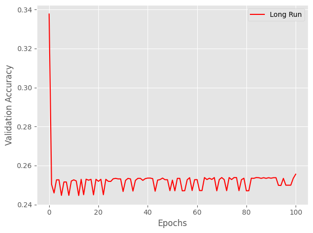

```python
# configuring, training, and evaluating a neural network with specific hyperparameters, and then visualizing its performance
vals = { 'n_hidden':30,
         'C':0.1, 'epochs':100, 'eta':0.0001,
         'alpha':0.001, 'decrease_const':1, 'minibatches':50,
         'shuffle':True,'random_state':1 }

nn_long_sigmoid = TLPBetterInitial(**vals) # use the TLPBetterInitial for better intial weights, and evaluate this performance

%time nn_long_sigmoid.fit(X_train, y_train, print_progress=1, XY_test=(X_test,y_test))
evals1=nn_long_sigmoid.val_score_
print_result(nn_long_sigmoid,X_train,y_train,X_test,y_test,title="Long Run",color="red")
```

[.5 points] Now (1) normalize the continuous numeric feature data. Use the example two-layer perceptron network from the class example and quantify performance using accuracy. Be sure that training converges by graphing the loss function versus the number of epochs.

```python
df_normalized = df.drop(['State', 'ChildPovertyClass'], axis=1)

# normalize the continuous numeric feature data
df_normalized = (df_normalized-df_normalized.mean()) / df_normalized.std()
df_normalized['State'] = df['State']
df_normalized['ChildPovertyClass'] = df['ChildPovertyClass']

df_normalized.head(10)
```

|  | TotalPop | Men | Women | Hispanic | White | Black | Native | Asian | Pacific | VotingAgeCitizen | Income | IncomeErr | IncomePerCap | IncomePerCapErr | Poverty | Professional | Service | Office | Construction | Production | Drive | Carpool | Transit | Walk | OtherTransp | WorkAtHome | MeanCommute | Employed | PrivateWork | … |
| --- | --- | --- | --- | --- | --- | --- | --- | --- | --- | --- | --- | --- | --- | --- | --- | --- | --- | --- | --- | --- | --- | --- | --- | --- | --- | --- | --- | --- | --- | --- |
| 0 | -1.186424 | -1.168560 | -1.167630 | -0.644718 | 0.815033 | -0.373213 | -0.161520 | -0.394912 | -0.143895 | -1.146470 | 0.219789 | 0.795775 | 0.148405 | 0.683473 | -0.430194 | 0.195906 | -0.407542 | -0.109663 | 0.258579 | -0.068793 | 1.224503 | -1.179501 | -0.461944 | -0.461120 | -0.758737 | -0.666355 | -0.222718 | -1.071600 | -0.667537 | … |
| 1 | -1.037121 | -0.924913 | -1.115167 | -0.701033 | -0.644414 | 1.911175 | -0.161520 | -0.417145 | -0.143895 | -0.984498 | -0.650027 | -0.959460 | -0.736592 | -0.600709 | 0.511180 | -0.336052 | 0.759391 | -0.091778 | -0.498506 | 0.326333 | 0.977185 | -0.043964 | -0.461944 | -0.556166 | -0.557595 | -1.223276 | -0.546859 | -1.097490 | -0.453898 | … |
| 2 | -0.483286 | -0.592172 | -0.362014 | -0.402130 | 0.002052 | 0.613754 | -0.028358 | -0.450495 | 0.250117 | -0.437100 | -0.469141 | -0.031756 | -0.595214 | -0.564266 | -0.108357 | -0.508938 | 0.069270 | 1.768236 | 0.107162 | -0.437578 | 0.830131 | -0.181012 | -0.461944 | -0.366074 | -0.436910 | -0.825475 | -0.420021 | -0.535045 | -0.780640 | … |
| 3 | -0.080580 | -0.166700 | 0.006116 | -0.332820 | 0.619134 | -0.285174 | -0.050552 | -0.506078 | -0.143895 | 0.076582 | -0.171249 | -0.869582 | -0.164014 | -0.354304 | -1.106052 | -0.435794 | -0.282065 | 0.426880 | -0.027431 | 0.866339 | 0.429075 | 0.367178 | -0.461944 | -0.271028 | 0.407884 | -0.666355 | -0.025415 | -0.207399 | -0.466465 | … |
| 4 | 2.521029 | 2.608869 | 2.358053 | -0.709697 | 0.527715 | 0.145755 | -0.161520 | -0.183697 | -0.143895 | 2.702506 | 0.230179 | 0.773551 | 0.393732 | 2.158560 | -0.309505 | 0.880801 | -0.633400 | -0.521012 | -0.969581 | 0.062916 | 0.736551 | 0.367178 | -0.461944 | -0.404092 | -0.638052 | -1.037635 | -0.715976 | 2.415559 | -1.019413 | … |
| 5 | -0.375989 | -0.381255 | -0.359346 | -0.618727 | 0.305696 | 0.548883 | -0.161520 | -0.528311 | -0.143895 | -0.300250 | -0.543114 | 1.051683 | -0.229022 | 0.059269 | -0.196862 | -0.688474 | 0.721748 | 0.999192 | -0.195672 | 0.023403 | 0.475864 | -0.885828 | -0.461944 | -0.423102 | 0.649254 | 0.898328 | -0.701883 | -0.640392 | 0.564029 | … |
| 6 | -0.467306 | -0.659448 | -0.265091 | -0.575407 | 0.544039 | 0.020647 | -0.028358 | -0.528311 | -0.143895 | -0.398756 | -0.651239 | 1.163622 | -0.734572 | -0.555908 | 0.881293 | -0.675175 | 2.026706 | -0.324280 | -0.616275 | -0.068793 | 0.876921 | 0.328022 | -0.461944 | -0.556166 | -0.758737 | -1.223276 | -1.364257 | -0.592182 | -0.265393 | … |
| 7 | -0.698793 | -0.626719 | -0.747927 | -0.566744 | 0.815033 | -0.285174 | 0.171385 | -0.528311 | -0.143895 | -0.646672 | 0.621709 | 0.605724 | 0.376439 | 0.309017 | -0.325597 | 0.694616 | -1.223140 | 1.285348 | -0.162024 | -0.911729 | 0.910342 | -0.924984 | -0.461944 | -0.556166 | -0.477138 | 0.155767 | -0.208625 | -0.635928 | -0.856042 | … |
| 8 | 3.145634 | 3.003431 | 3.188567 | -0.688037 | 0.668109 | 0.094785 | -0.161520 | -0.417145 | -0.143895 | 3.376176 | 0.108780 | -0.165592 | -0.255341 | -0.689642 | -0.108357 | 0.082865 | 0.169651 | -0.681975 | 0.006218 | 0.141941 | 0.883605 | -0.122277 | -0.461944 | -0.556166 | -0.758737 | -0.639835 | 0.185982 | 2.478052 | -1.182784 | … |
| 9 | 0.786927 | 0.842432 | 0.708584 | -0.705365 | 0.811768 | -0.164699 | 0.016029 | -0.494961 | -0.143895 | 1.037173 | -0.381861 | 0.952163 | -0.248714 | -0.137320 | -0.534791 | -0.216361 | -0.771424 | -0.592551 | -0.481682 | 2.064889 | 0.088177 | 0.504226 | -0.461944 | -0.556166 | 1.252679 | 0.341407 | 1.341614 | 0.624663 | 0.111617 | … |

```python
# split training and testing data. Test 20%, Train 80%
X = np.array(df_normalized.drop(['ChildPovertyClass'], axis=1))
y = df_normalized['ChildPovertyClass']

X_train, X_test, y_train, y_test = train_test_split(X, y, test_size=0.2, train_size=0.8,
                                                    stratify=df_normalized['ChildPovertyClass'])
# reset the indexes to be sequential
y_train = y_train.reset_index(drop=True)
y_test = y_test.reset_index(drop=True)
```

```
Epoch: 100/100
```

```
CPU times: user 31.5 s, sys: 21 s, total: 52.4 s
Wall time: 33.6 s
=================
Long Run :
Resubstitution acc: 0.6548973768350123
{0, 1, 2, 3}
Validation acc: 0.6508525852585259
{0, 1, 2, 3}
```

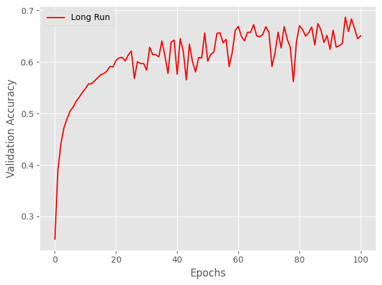

```python
# run the neural network after fine tuning it with values
# print the new results that use the normalized df. The new df's continous numeric feature data is normalized
# so the result will be different than the first test.
vals = { 'n_hidden':30,
         'C':0.1, 'epochs':100, 'eta':0.0001,
         'alpha':0.001, 'decrease_const': 1, 'minibatches':50,
         'shuffle':True,'random_state':1 }

nn_long_sigmoid = TLPBetterInitial(**vals)

%time nn_long_sigmoid.fit(X_train, y_train, print_progress=1, XY_test=(X_test,y_test))
# y_hat_N =nn_long_sigmoid.predict(X_train)
# y_test_N = y_test
evals2=nn_long_sigmoid.val_score_

print_result(nn_long_sigmoid,X_train,y_train,X_test,y_test,title="Long Run",color="red")
```

[.5 points] Now(1) normalize the continuous numeric feature data AND (2) one hot encode the categorical data. Use the example two-layer perceptron network from the class example and quantify performance using accuracy. Be sure that training converges by graphing the loss function versus the number of epochs.

```python
# add one hot encoding to the df with the pd.get_dummies function
one_hot = pd.get_dummies(df_normalized['State'], columns=['State'], dtype=int)
df_one_hot = df_normalized.join(one_hot)
df_one_hot.drop(['State'], axis=1, inplace=True)

df_one_hot.head(10)
```

|  | TotalPop | Men | Women | Hispanic | White | Black | Native | Asian | Pacific | VotingAgeCitizen | Income | IncomeErr | IncomePerCap | IncomePerCapErr | Poverty | Professional | Service | Office | Construction | Production | Drive | Carpool | Transit | Walk | OtherTransp | WorkAtHome | MeanCommute | Employed | PrivateWork | … |
| --- | --- | --- | --- | --- | --- | --- | --- | --- | --- | --- | --- | --- | --- | --- | --- | --- | --- | --- | --- | --- | --- | --- | --- | --- | --- | --- | --- | --- | --- | --- |
| 0 | -1.186424 | -1.168560 | -1.167630 | -0.644718 | 0.815033 | -0.373213 | -0.161520 | -0.394912 | -0.143895 | -1.146470 | 0.219789 | 0.795775 | 0.148405 | 0.683473 | -0.430194 | 0.195906 | -0.407542 | -0.109663 | 0.258579 | -0.068793 | 1.224503 | -1.179501 | -0.461944 | -0.461120 | -0.758737 | -0.666355 | -0.222718 | -1.071600 | -0.667537 | … |
| 1 | -1.037121 | -0.924913 | -1.115167 | -0.701033 | -0.644414 | 1.911175 | -0.161520 | -0.417145 | -0.143895 | -0.984498 | -0.650027 | -0.959460 | -0.736592 | -0.600709 | 0.511180 | -0.336052 | 0.759391 | -0.091778 | -0.498506 | 0.326333 | 0.977185 | -0.043964 | -0.461944 | -0.556166 | -0.557595 | -1.223276 | -0.546859 | -1.097490 | -0.453898 | … |
| 2 | -0.483286 | -0.592172 | -0.362014 | -0.402130 | 0.002052 | 0.613754 | -0.028358 | -0.450495 | 0.250117 | -0.437100 | -0.469141 | -0.031756 | -0.595214 | -0.564266 | -0.108357 | -0.508938 | 0.069270 | 1.768236 | 0.107162 | -0.437578 | 0.830131 | -0.181012 | -0.461944 | -0.366074 | -0.436910 | -0.825475 | -0.420021 | -0.535045 | -0.780640 | … |
| 3 | -0.080580 | -0.166700 | 0.006116 | -0.332820 | 0.619134 | -0.285174 | -0.050552 | -0.506078 | -0.143895 | 0.076582 | -0.171249 | -0.869582 | -0.164014 | -0.354304 | -1.106052 | -0.435794 | -0.282065 | 0.426880 | -0.027431 | 0.866339 | 0.429075 | 0.367178 | -0.461944 | -0.271028 | 0.407884 | -0.666355 | -0.025415 | -0.207399 | -0.466465 | … |
| 4 | 2.521029 | 2.608869 | 2.358053 | -0.709697 | 0.527715 | 0.145755 | -0.161520 | -0.183697 | -0.143895 | 2.702506 | 0.230179 | 0.773551 | 0.393732 | 2.158560 | -0.309505 | 0.880801 | -0.633400 | -0.521012 | -0.969581 | 0.062916 | 0.736551 | 0.367178 | -0.461944 | -0.404092 | -0.638052 | -1.037635 | -0.715976 | 2.415559 | -1.019413 | … |
| 5 | -0.375989 | -0.381255 | -0.359346 | -0.618727 | 0.305696 | 0.548883 | -0.161520 | -0.528311 | -0.143895 | -0.300250 | -0.543114 | 1.051683 | -0.229022 | 0.059269 | -0.196862 | -0.688474 | 0.721748 | 0.999192 | -0.195672 | 0.023403 | 0.475864 | -0.885828 | -0.461944 | -0.423102 | 0.649254 | 0.898328 | -0.701883 | -0.640392 | 0.564029 | … |
| 6 | -0.467306 | -0.659448 | -0.265091 | -0.575407 | 0.544039 | 0.020647 | -0.028358 | -0.528311 | -0.143895 | -0.398756 | -0.651239 | 1.163622 | -0.734572 | -0.555908 | 0.881293 | -0.675175 | 2.026706 | -0.324280 | -0.616275 | -0.068793 | 0.876921 | 0.328022 | -0.461944 | -0.556166 | -0.758737 | -1.223276 | -1.364257 | -0.592182 | -0.265393 | … |
| 7 | -0.698793 | -0.626719 | -0.747927 | -0.566744 | 0.815033 | -0.285174 | 0.171385 | -0.528311 | -0.143895 | -0.646672 | 0.621709 | 0.605724 | 0.376439 | 0.309017 | -0.325597 | 0.694616 | -1.223140 | 1.285348 | -0.162024 | -0.911729 | 0.910342 | -0.924984 | -0.461944 | -0.556166 | -0.477138 | 0.155767 | -0.208625 | -0.635928 | -0.856042 | … |
| 8 | 3.145634 | 3.003431 | 3.188567 | -0.688037 | 0.668109 | 0.094785 | -0.161520 | -0.417145 | -0.143895 | 3.376176 | 0.108780 | -0.165592 | -0.255341 | -0.689642 | -0.108357 | 0.082865 | 0.169651 | -0.681975 | 0.006218 | 0.141941 | 0.883605 | -0.122277 | -0.461944 | -0.556166 | -0.758737 | -0.639835 | 0.185982 | 2.478052 | -1.182784 | … |
| 9 | 0.786927 | 0.842432 | 0.708584 | -0.705365 | 0.811768 | -0.164699 | 0.016029 | -0.494961 | -0.143895 | 1.037173 | -0.381861 | 0.952163 | -0.248714 | -0.137320 | -0.534791 | -0.216361 | -0.771424 | -0.592551 | -0.481682 | 2.064889 | 0.088177 | 0.504226 | -0.461944 | -0.556166 | 1.252679 | 0.341407 | 1.341614 | 0.624663 | 0.111617 | … |

```python
# get model ready with testing size 20% & training size 80%
X = np.array(df_one_hot.drop(['ChildPovertyClass'], axis=1))
y = df_one_hot['ChildPovertyClass']

X_train, X_test, y_train, y_test = train_test_split(X, y, test_size=0.2, train_size=0.8,
                                                    stratify=df_one_hot['ChildPovertyClass'])

y_train = y_train.reset_index(drop=True)
y_test = y_test.reset_index(drop=True)
```

```
Epoch: 100/100
```

```
CPU times: user 41.6 s, sys: 25.9 s, total: 1min 7s
Wall time: 45.9 s
=================
Long Run :
Resubstitution acc: 0.7116237494413312
{0, 1, 2, 3}
Validation acc: 0.7145902090209021
{0, 1, 2, 3}
```

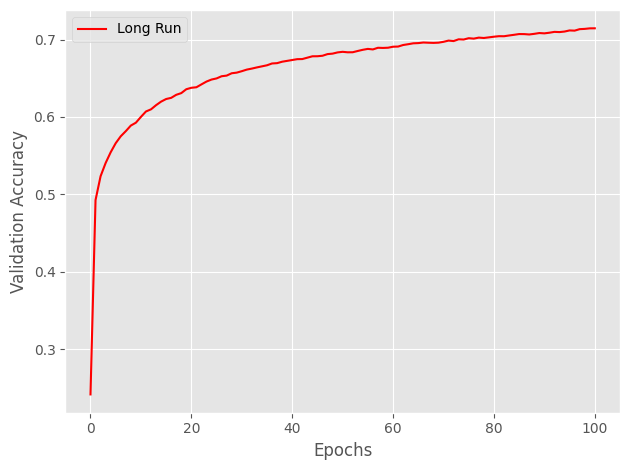

```python
# tune the model, and run with normalized continous numeric features + one hot encoding for a new result
vals = { 'n_hidden':30,
         'C':0.1, 'epochs':100, 'eta':0.0001,
         'alpha':0.001, 'decrease_const': 1, 'minibatches':50,
         'shuffle':True,'random_state':1 }

nn_long_sigmoid = TLPBetterInitial(**vals)

%time nn_long_sigmoid.fit(X_train, y_train, print_progress=1, XY_test=(X_test,y_test))
# y_hat_OH =nn_long_sigmoid.predict(X_train)
# y_test_OH = y_test
evals3=nn_long_sigmoid.val_score_
print_result(nn_long_sigmoid,X_train,y_train,X_test,y_test,title="Long Run",color="red")
```

[1 points] Compare the performance of the three models you just trained. Are there any meaningful differences in performance? Explain, in your own words, why these models have (or do not have) different performances. Use one-hot encoding and normalization on the dataset for the remainder of this lab assignment.

```python
# compare the scores of the three models
#===================================================
# Enter your code below
from sklearn.model_selection import cross_val_score
mean_score1= np.mean(evals1)
mean_score2= np.mean(evals2)
mean_score3= np.mean(evals3)
print('Mean Score for Model 1:', np.mean(evals1))
print('Mean Score for Model 2:', np.mean(evals2))
print('Mean Score for Model 3:', np.mean(evals3))

# t = 2.26 / np.sqrt(10)
t= 1.96

# model 1 and 2
e_list = [(1-evals1[i]) - (1-evals2[i])for i in range(len(evals1))]
# e = (1-evals1) - (1-evals2)
stdtot = np.std(e_list)
dbar = np.mean(e_list)
print('Interval for Model 1 and 2:', dbar-t*stdtot, dbar+t*stdtot)

# # model 2 and 3
e_list = [(1-evals2[i]) - (1-evals3[i])for i in range(len(evals1))]
# e = (1-evals1) - (1-evals2)
stdtot = np.std(e_list)
dbar = np.mean(e_list)
print('Interval for Model 2 and 3:', dbar-t*stdtot, dbar+t*stdtot)

# # model 3 and 1
e_list = [(1-evals3[i]) - (1-evals1[i])for i in range(len(evals1))]
# e = (1-evals1) - (1-evals2)
stdtot = np.std(e_list)
dbar = np.mean(e_list)
print('Interval for Model 3 and 1:', dbar-t*stdtot, dbar+t*stdtot)

#===================================================
```

```
Mean Score for Model 1: 0.2523030149549608
Mean Score for Model 2: 0.6095378721040421
Mean Score for Model 3: 0.6641757616355695
Interval for Model 1 and 2: 0.2246020400758635 0.4898676742222988
Interval for Model 2 and 3: 0.009135378936569488 0.10014040012648535
Interval for Model 3 and 1: -0.5443407830295699 -0.2794047103316473
```

Model 1 is the original model. Model 2 is the model with the normalized data. Model 3 is the model with the normalized data & one-hot encoded categorical columns.

The mean scores of the three models show a large difference in score. The mean scores provide a "point estimate" of each models mean score, meaning it is a best estimate. Two models could have differing mean scores by chance, & you do not know how much the mean scores would change if new data was introduced into the models. This uncertainty means that it is good practice to verify the mean scores.

To verify the mean scores, the confidence intervals show the lower and upper bounds between two models. This is a way to compare two model to check for significant statistical differences. The confidence intervals compare the models as such: model 1 to model 2, model 2 to model 3, model 3 to model 1.

If these confidence intervals contain a zero in the upper and lower bound range, then the null hypothesis is true. This null hypothesis means that the models may have no significant statistical difference, and any difference seen could be based on chance. Conversely, if the lower and upper bounds of a model comparison do not contain zero, then there is a significant difference between the model statistics and the null hypothesis is rejected as a valid hypothesis.

Our confidence intervals between all model comparisons do not contain zero in their lower or upper bounds, which means that there is a statistical difference between all three models.

## Modeling

[1 points] Add support for a third layer in the multi-layer perceptron. Add support for saving (and plotting after training is completed) the average magnitude of the gradient for each layer, for each epoch (like we did in the flipped module for back propagation). For magnitude calculation, you are free to use either the average absolute values or the L1/L2 norm. Quantify the performance of the model and graph the magnitudes for each layer versus the number of epochs.

```python
class TLPThreeLayer(TwoLayerPerceptronBase):
    def __init__(self, alpha=0.0, decrease_const=0.1,
                 decrease_iter = 20, shuffle=True,
                 minibatches=1, **kwds):
        # need to add to the original initializer
        self.alpha = alpha
        self.decrease_const = decrease_const
        self.decrease_iter = decrease_iter
        self.shuffle = shuffle
        self.minibatches = minibatches
        # but keep other keywords
        super().__init__(**kwds)

    def _L2_reg(self, lambda_, W1, W2, W3): # L2 regularization for weight penalization
        """Compute L2-regularization cost for three layers."""
        # Only compute for non-bias terms
        return (lambda_ / 2.0) * np.sqrt(np.mean(W1[:, 1:] ** 2) + np.mean(W2[:, 1:] ** 2) + np.mean(W3[:, 1:] ** 2))

    def _cost(self, A4, Y_enc, W1, W2, W3):
        """Get the objective function value for three layers."""
        cost = -np.mean(np.nan_to_num((Y_enc * np.log(A4) + (1 - Y_enc) * np.log(1 - A4))))
        L2_term = self._L2_reg(self.l2_C, W1, W2, W3)
        return cost + L2_term

    def _initialize_weights(self):
        """Initialize weights Glorot and He normalization for three layers."""
        # Initialize weights for the first layer
        init_bound1 = 4 * np.sqrt(6 / (self.n_hidden + self.n_features_))
        W1 = np.random.uniform(-init_bound1, init_bound1, (self.n_hidden, self.n_features_))

        # Initialize weights for the second layer
        init_bound2 = 4 * np.sqrt(6 / (self.n_hidden + self.n_hidden))
        W2 = np.random.uniform(-init_bound2, init_bound2, (self.n_hidden, self.n_hidden))

        # Initialize weights for the final layer
        init_bound3 = 4 * np.sqrt(6 / (self.n_output_ + self.n_hidden))
        W3 = np.random.uniform(-init_bound3, init_bound3, (self.n_output_, self.n_hidden))

        # set these to zero to start so that
        # they do not immediately saturate the neurons
        b1 = np.zeros((self.n_hidden, 1))
        b2 = np.zeros((self.n_hidden, 1))
        b3 = np.zeros((self.n_output_, 1))

        return W1, W2, W3, b1, b2, b3

    def _feedforward(self, X, W1, W2, W3, b1, b2, b3):
        """Compute feedforward step
        -----------
        X : Input layer with original features.
        W1: Weight matrix for input layer -> hidden layer.
        W2: Weight matrix for hidden layer -> hidden layer.
        W3: Weight matrix for hidden layer -> output layer.
        ----------
        a1-a4 : activations into layer (or output layer)
        z1-z3 : layer inputs

        """
        A1 = X.T
        Z1 = W1 @ A1 + b1
        A2 = self._sigmoid(Z1)
        Z2 = W2 @ A2 + b2
        A3 = self._sigmoid(Z2)
        Z3 = W3 @ A3 + b3
        A4 = self._sigmoid(Z3) # now three layers, so A4 is the final output
        return A1, Z1, A2, Z2, A3, Z3, A4

    def _get_gradient(self, A1, A2, A3, A4, Z1, Z2, Z3, Y_enc, W1, W2, W3):
        """Compute gradient step using backpropagation for three layers."""
        # Vectorized backpropagation
        V3 = A4 - Y_enc
        V2 = A3 * (1 - A3) * (W3.T @ V3)
        V1 = A2 * (1 - A2) * (W2.T @ V2)

        gradW3 = V3 @ A3.T
        gradW2 = V2 @ A2.T
        gradW1 = V1 @ A1.T

        gradb3 = np.sum(V3, axis=1).reshape((-1,1))
        gradb2 = np.sum(V2, axis=1).reshape((-1,1))
        gradb1 = np.sum(V1, axis=1).reshape((-1,1))

        # regularize weights that are not bias terms
        gradW1 += W1 * self.l2_C
        gradW2 += W2 * self.l2_C
        gradW3 += W3 * self.l2_C

        return gradW1, gradW2, gradW3, gradb1, gradb2, gradb3

    def fit(self, X, y, print_progress=False, XY_test=None):
        """ Learn weights from training data. With mini-batch for three layers."""
        X_data, y_data = X.copy(), y.copy()
        Y_enc = self._encode_labels(y)

        # Initialize weights and setup matrices for three layers
        self.n_features_ = X_data.shape[1]
        self.n_output_ = Y_enc.shape[0]
        self.W1, self.W2, self.W3, self.b1, self.b2, self.b3 = self._initialize_weights()

        rho_W1_prev = np.zeros(self.W1.shape)
        rho_W2_prev = np.zeros(self.W2.shape)
        rho_W3_prev = np.zeros(self.W3.shape)

        # Track gradient magnitude - save the gradients for later use here
        # Tracking across epochs can help diagnose training issues across the model: vaishing gradient, exploding gradient
        self.grad_w1_ = np.zeros(self.epochs)
        self.grad_w2_ = np.zeros(self.epochs)
        self.grad_w3_ = np.zeros(self.epochs)

        self.cost_ = []
        self.score_ = []
        # Get starting accuracy
        self.score_.append(accuracy_score(y_data, self.predict(X_data)))
        # Keep track of validation, if given
        if XY_test is not None:
            X_test = XY_test[0].copy()
            y_test = XY_test[1].copy()
            self.val_score_ = []
            self.val_score_.append(accuracy_score(y_test, self.predict(X_test)))
            self.val_cost_ = []

        for i in range(self.epochs):

            # adaptive learning rate
            # decrease at certain epochs
            eta = self.eta * self.decrease_const**(np.floor(i/self.decrease_iter))

            if print_progress > 0 and (i + 1) % print_progress == 0:
                sys.stderr.write('\rEpoch: %d/%d' % (i + 1, self.epochs))
                sys.stderr.flush()

            if self.shuffle:
                idx_shuffle = np.random.permutation(y_data.shape[0])
                X_data, Y_enc, y_data = X_data[idx_shuffle], Y_enc[:, idx_shuffle], y_data[idx_shuffle]

            mini = np.array_split(range(y_data.shape[0]), self.minibatches)
            mini_cost = []
            for idx in mini:

                # Feedforward for three layers
                A1, Z1, A2, Z2, A3, Z3, A4 = self._feedforward(X_data[idx],
                                                               self.W1,
                                                               self.W2,
                                                               self.W3,
                                                               self.b1,
                                                               self.b2,
                                                               self.b3
                                                              )

                cost = self._cost(A4, Y_enc[:, idx], self.W1, self.W2, self.W3)
                mini_cost.append(cost)  # This appends cost of mini-batch only

                # Compute gradient via backpropagation for three layers
                gradW1, gradW2, gradW3, gradb1, gradb2, gradb3 = self._get_gradient(A1=A1, A2=A2, A3=A3, A4=A4,
                                                                                    Z1=Z1, Z2=Z2, Z3=Z3,
                                                                                    Y_enc=Y_enc[:, idx],
                                                                                    W1=self.W1, W2=self.W2, W3=self.W3
                                                                                   )

                # Track the magnitude of the gradient - update the tracked gradient magnitudes
                # put the newly calculated gradient values in our saved gradients with np.abs below to get the absolute value of the values before saving them
                # getting the absolute value means we are considering only the size and not the direction of the gradient
                # considering the size only helps us determine if the gradient is vanishing (too small) or explosive (too big)
                # magnitude calculation using absolute values on the gradients
                # gradients influence the magnitude (size of the change) and direction (which way the weights should get adjusted to minimize the loss)
                self.grad_w1_[i] = np.abs(gradW1).mean()
                self.grad_w2_[i] = np.abs(gradW2).mean()
                self.grad_w3_[i] = np.abs(gradW3).mean()

                # Momentum calculations - use eta to control rho scaling for momentum
                # Momentum combines current gradient with portion from previous update, speeding up convergence of gradients
                rho_W1, rho_W2, rho_W3 = eta * gradW1, eta * gradW2, eta * gradW3
                self.W1 -= (rho_W1 + (self.alpha * rho_W1_prev))
                self.W2 -= (rho_W2 + (self.alpha * rho_W2_prev))
                self.W3 -= (rho_W3 + (self.alpha * rho_W3_prev))

                # no need for momentum in bias
                # these values need to change abruptly and
                # do not influence sensitivity backward
                self.b1 -= eta * gradb1
                self.b2 -= eta * gradb2
                self.b3 -= eta * gradb3

                # update previous parameters
                rho_W1_prev, rho_W2_prev, rho_W3_prev = rho_W1, rho_W2, rho_W3

            self.cost_.append(np.mean(mini_cost))
            self.score_.append(accuracy_score(y_data, self.predict(X_data)))
            if XY_test is not None:
                yhat = self.predict(X_test)
                self.val_score_.append(accuracy_score(y_test, yhat))

        return self

    def predict(self, X):
        """Predict class labels"""
        _, _, _, _, _, _, A4 = self._feedforward(X, self.W1, self.W2, self.W3, self.b1, self.b2, self.b3)
        y_pred = np.argmax(A4, axis=0)
        return y_pred
```

```
Epoch: 200/200
```

```
CPU times: user 1min 54s, sys: 1min 5s, total: 2min 59s
Wall time: 1min 49s
=================
Long Run :
Resubstitution acc: 0.7358957609928835
{0, 1, 2, 3}
Validation acc: 0.7350797579757976
{0, 1, 2, 3}
```

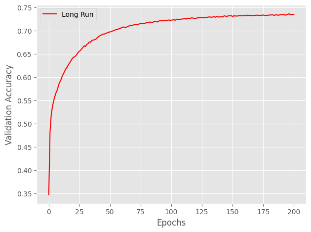

```python
# n_hidden is the # of neurons in the hidden layer
# C: regularization strength for L2 Regularization
# epochs is the number of iterations
# eta is the learning rate: used in the fit method to scale the weights a certain amount
# random_state is a seed for random number generation. Set to none to produce a different set of random numbers each run.
# random_state is passed into the np.random.seed function as a parameter to control the random numbers that are generated by numpy
vals = { 'n_hidden':30,
         'C':0.1, 'epochs':200, 'eta':0.0001,
         'alpha':0.001, 'decrease_const':1, 'minibatches':50,
         'shuffle':True,'random_state':1 }

nn_long_sigmoid = TLPThreeLayer(**vals)

%time nn_long_sigmoid.fit(X_train, y_train, print_progress=1, XY_test=(X_test,y_test))
print_result(nn_long_sigmoid,X_train,y_train,X_test,y_test,title="Long Run",color="red")
```

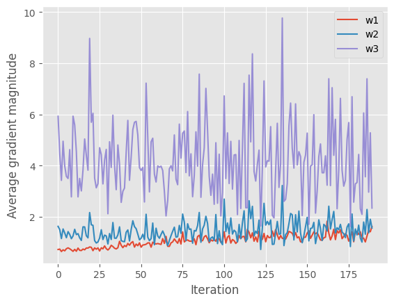

```python
# now we can save the gradient on each layer
# we can print out the average gradient on each layer in a graph for viewing
ax = plt.subplot(1,1,1)
plt.plot(np.abs(nn_long_sigmoid.grad_w1_[10:]), label='w1')
plt.plot(np.abs(nn_long_sigmoid.grad_w2_[10:]), label='w2')
plt.plot(np.abs(nn_long_sigmoid.grad_w3_[10:]), label='w3')
plt.legend()
plt.ylabel('Average gradient magnitude')
plt.xlabel('Iteration')
plt.show()
```

[1 points] Repeat the previous step, adding support for a fourth layer.

```python
class TLPFourLayer(TwoLayerPerceptronBase): # fourth layer support
    def __init__(self, alpha=0.0, decrease_const=0.1,
                 decrease_iter = 20, shuffle=True,
                 minibatches=1, **kwds):
        # need to add to the original initializer
        self.alpha = alpha
        self.decrease_const = decrease_const
        self.decrease_iter = decrease_iter
        self.shuffle = shuffle
        self.minibatches = minibatches
        # but keep other keywords
        super().__init__(**kwds)

    def _L2_reg(self, lambda_, W1, W2, W3, W4):
        """Compute L2-regularization cost for four layers."""
        # Only compute for non-bias terms
        return (lambda_ / 2.0) * np.sqrt(np.mean(W1[:, 1:] ** 2) + np.mean(W2[:, 1:] ** 2) + np.mean(W3[:, 1:] ** 2) + np.mean(W4[:, 1:] ** 2))

    def _cost(self, A5, Y_enc, W1, W2, W3, W4):
        """Get the objective function value for four layers."""
        cost = -np.mean(np.nan_to_num((Y_enc * np.log(A5) + (1 - Y_enc) * np.log(1 - A5))))
        L2_term = self._L2_reg(self.l2_C, W1, W2, W3, W4)
        return cost + L2_term

    def _initialize_weights(self):
        """Initialize weights Glorot and He normalization for four layers."""
        # Initialize weights for the first layer
        init_bound1 = 4 * np.sqrt(6 / (self.n_hidden + self.n_features_))
        W1 = np.random.uniform(-init_bound1, init_bound1, (self.n_hidden, self.n_features_))

        # Initialize weights for the second layer
        init_bound2 = 4 * np.sqrt(6 / (self.n_hidden + self.n_hidden))
        W2 = np.random.uniform(-init_bound2, init_bound2, (self.n_hidden, self.n_hidden))

        # Initialize weights for the third layer
        init_bound3 = 4 * np.sqrt(6 / (self.n_hidden + self.n_hidden))
        W3 = np.random.uniform(-init_bound3, init_bound3, (self.n_hidden, self.n_hidden))

        # Initialize weights for the final layer
        init_bound4 = 4 * np.sqrt(6 / (self.n_output_ + self.n_hidden))
        W4 = np.random.uniform(-init_bound4, init_bound4, (self.n_output_, self.n_hidden))

        # set these to zero to start so that
        # they do not immediately saturate the neurons
        b1 = np.zeros((self.n_hidden, 1))
        b2 = np.zeros((self.n_hidden, 1))
        b3 = np.zeros((self.n_hidden, 1))
        b4 = np.zeros((self.n_output_, 1))

        return W1, W2, W3, W4, b1, b2, b3, b4

    def _feedforward(self, X, W1, W2, W3, W4, b1, b2, b3, b4):
        A1 = X.T
        Z1 = W1 @ A1 + b1
        A2 = self._sigmoid(Z1)
        Z2 = W2 @ A2 + b2
        A3 = self._sigmoid(Z2)
        Z3 = W3 @ A3 + b3
        A4 = self._sigmoid(Z3)
        Z4 = W4 @ A4 + b4
        A5 = self._sigmoid(Z4) # since we have four layers, A5 is new final output
        return A1, Z1, A2, Z2, A3, Z3, A4, Z4, A5

    def _get_gradient(self, A1, A2, A3, A4, A5, Z1, Z2, Z3, Z4, Y_enc, W1, W2, W3, W4):
        """Compute gradient step using backpropagation for three layers."""
        # Vectorized backpropagation
        V4 = A5 - Y_enc
        V3 = A4 * (1 - A4) * (W4.T @ V4)
        V2 = A3 * (1 - A3) * (W3.T @ V3)
        V1 = A2 * (1 - A2) * (W2.T @ V2)

        gradW4 = V4 @ A4.T
        gradW3 = V3 @ A3.T
        gradW2 = V2 @ A2.T
        gradW1 = V1 @ A1.T

        gradb4 = np.sum(V4, axis=1).reshape((-1,1))
        gradb3 = np.sum(V3, axis=1).reshape((-1,1))
        gradb2 = np.sum(V2, axis=1).reshape((-1,1))
        gradb1 = np.sum(V1, axis=1).reshape((-1,1))

        # regularize weights that are not bias terms
        gradW1 += W1 * self.l2_C
        gradW2 += W2 * self.l2_C
        gradW3 += W3 * self.l2_C
        gradW4 += W4 * self.l2_C

        return gradW1, gradW2, gradW3, gradW4, gradb1, gradb2, gradb3, gradb4

    def fit(self, X, y, print_progress=False, XY_test=None):
        """ Learn weights from training data. With mini-batch for three layers."""
        X_data, y_data = X.copy(), y.copy()
        Y_enc = self._encode_labels(y)

        # Initialize weights and setup matrices for three layers
        self.n_features_ = X_data.shape[1]
        self.n_output_ = Y_enc.shape[0]
        self.W1, self.W2, self.W3, self.W4, self.b1, self.b2, self.b3, self.b4 = self._initialize_weights()

        rho_W1_prev = np.zeros(self.W1.shape)
        rho_W2_prev = np.zeros(self.W2.shape)
        rho_W3_prev = np.zeros(self.W3.shape)
        rho_W4_prev = np.zeros(self.W4.shape)

        # Track gradient magnitude
        self.grad_w1_ = np.zeros(self.epochs)
        self.grad_w2_ = np.zeros(self.epochs)
        self.grad_w3_ = np.zeros(self.epochs)
        self.grad_w4_ = np.zeros(self.epochs)

        self.cost_ = []
        self.score_ = []
        # Get starting accuracy
        self.score_.append(accuracy_score(y_data, self.predict(X_data)))
        # Keep track of validation, if given
        if XY_test is not None:
            X_test = XY_test[0].copy()
            y_test = XY_test[1].copy()
            self.val_score_ = []
            self.val_score_.append(accuracy_score(y_test, self.predict(X_test)))
            self.val_cost_ = []

        for i in range(self.epochs):

            # adaptive learning rate
            # decrease at certain epochs
            eta = self.eta * self.decrease_const**(np.floor(i/self.decrease_iter))

            if print_progress > 0 and (i + 1) % print_progress == 0:
                sys.stderr.write('\rEpoch: %d/%d' % (i + 1, self.epochs))
                sys.stderr.flush()

            if self.shuffle:
                idx_shuffle = np.random.permutation(y_data.shape[0])
                X_data, Y_enc, y_data = X_data[idx_shuffle], Y_enc[:, idx_shuffle], y_data[idx_shuffle]

            mini = np.array_split(range(y_data.shape[0]), self.minibatches)
            mini_cost = []
            for idx in mini:

                # Feedforward for three layers
                A1, Z1, A2, Z2, A3, Z3, A4, Z4, A5 = self._feedforward(X_data[idx],
                                                               self.W1,
                                                               self.W2,
                                                               self.W3,
                                                               self.W4,
                                                               self.b1,
                                                               self.b2,
                                                               self.b3,
                                                               self.b4
                                                              )

                cost = self._cost(A5, Y_enc[:, idx], self.W1, self.W2, self.W3, self.W4)
                mini_cost.append(cost)  # This appends cost of mini-batch only

                # Compute gradient via backpropagation for three layers
                gradW1, gradW2, gradW3, gradW4, gradb1, gradb2, gradb3, gradb4 = self._get_gradient(A1=A1, A2=A2, A3=A3, A4=A4, A5=A5,
                                                                                    Z1=Z1, Z2=Z2, Z3=Z3, Z4=Z4,
                                                                                    Y_enc=Y_enc[:, idx],
                                                                                    W1=self.W1, W2=self.W2, W3=self.W3, W4=self.W4
                                                                                   )

                # Track the magnitude of the gradient
                self.grad_w1_[i] = np.abs(gradW1).mean()
                self.grad_w2_[i] = np.abs(gradW2).mean()
                self.grad_w3_[i] = np.abs(gradW3).mean()
                self.grad_w4_[i] = np.abs(gradW4).mean()

                # Momentum calculations
                rho_W1, rho_W2, rho_W3, rho_W4 = eta * gradW1, eta * gradW2, eta * gradW3, eta * gradW4
                self.W1 -= (rho_W1 + (self.alpha * rho_W1_prev))
                self.W2 -= (rho_W2 + (self.alpha * rho_W2_prev))
                self.W3 -= (rho_W3 + (self.alpha * rho_W3_prev))
                self.W4 -= (rho_W4 + (self.alpha * rho_W4_prev))

                # no need for momentum in bias
                # these values need to change abruptly and
                # do not influence sensitivity backward
                self.b1 -= eta * gradb1
                self.b2 -= eta * gradb2
                self.b3 -= eta * gradb3
                self.b4 -= eta * gradb4

                # update previous parameters
                rho_W1_prev, rho_W2_prev, rho_W3_prev, rho_W4_prev = rho_W1, rho_W2, rho_W3, rho_W4

            self.cost_.append(np.mean(mini_cost))
            self.score_.append(accuracy_score(y_data, self.predict(X_data)))
            if XY_test is not None:
                yhat = self.predict(X_test)
                self.val_score_.append(accuracy_score(y_test, yhat))

        return self

    def predict(self, X):
        """Predict class labels"""
        _, _, _, _, _, _, _, _, A5 = self._feedforward(X, self.W1, self.W2, self.W3, self.W4, self.b1, self.b2, self.b3, self.b4)
        y_pred = np.argmax(A5, axis=0)
        return y_pred
```

```
Epoch: 200/200
```

```
CPU times: user 2min 30s, sys: 1min 23s, total: 3min 54s
Wall time: 2min 24s
=================
Long Run :
Resubstitution acc: 0.7369443393956063
{0, 1, 2, 3}
Validation acc: 0.732948294829483
{0, 1, 2, 3}
```

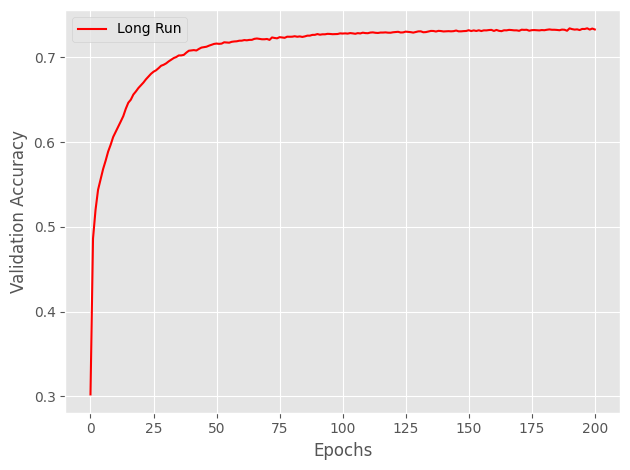

```python
# tune the model and run it
vals = { 'n_hidden':30,
         'C':0.1, 'epochs':200, 'eta':0.0001,
         'alpha':0.001, 'decrease_const':1, 'minibatches':50,
         'shuffle':True,'random_state':1 }

nn_long_sigmoid = TLPFourLayer(**vals)

%time nn_long_sigmoid.fit(X_train, y_train, print_progress=1, XY_test=(X_test,y_test))
print_result(nn_long_sigmoid,X_train,y_train,X_test,y_test,title="Long Run",color="red")
```

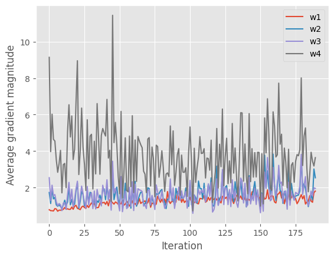

```python
# display the average gradient magnitude across layers
ax = plt.subplot(1,1,1)
plt.plot(np.abs(nn_long_sigmoid.grad_w1_[10:]), label='w1')
plt.plot(np.abs(nn_long_sigmoid.grad_w2_[10:]), label='w2')
plt.plot(np.abs(nn_long_sigmoid.grad_w3_[10:]), label='w3')
plt.plot(np.abs(nn_long_sigmoid.grad_w4_[10:]), label='w4')
plt.legend()
plt.ylabel('Average gradient magnitude')
plt.xlabel('Iteration')
plt.show()
```

[1 points] Repeat the previous step, adding support for a fifth layer.

```python
class TLPFiveLayer(TLPFourLayer): # add fifth layer support
    def _L2_reg(self, lambda_, W1, W2, W3, W4, W5):
        """Compute L2-regularization cost for five layers."""
        # Only compute for non-bias terms
        return (lambda_ / 2.0) * np.sqrt(np.mean(W1[:, 1:] ** 2) + np.mean(W2[:, 1:] ** 2) + np.mean(W3[:, 1:] ** 2) + np.mean(W4[:, 1:] ** 2) + np.mean(W5[:, 1:] ** 2))

    def _cost(self, A6, Y_enc, W1, W2, W3, W4, W5):
        """Get the objective function value for four layers."""
        cost = -np.mean(np.nan_to_num((Y_enc * np.log(A6) + (1 - Y_enc) * np.log(1 - A6))))
        L2_term = self._L2_reg(self.l2_C, W1, W2, W3, W4, W5)
        return cost + L2_term

    def _initialize_weights(self):
        """Initialize weights Glorot and He normalization for five layers."""
        # Initialize weights for the first layer
        init_bound1 = 4 * np.sqrt(6 / (self.n_hidden + self.n_features_))
        W1 = np.random.uniform(-init_bound1, init_bound1, (self.n_hidden, self.n_features_))

        # Initialize weights for the second layer
        init_bound2 = 4 * np.sqrt(6 / (self.n_hidden + self.n_hidden))
        W2 = np.random.uniform(-init_bound2, init_bound2, (self.n_hidden, self.n_hidden))

        # Initialize weights for the third layer
        init_bound3 = 4 * np.sqrt(6 / (self.n_hidden + self.n_hidden))
        W3 = np.random.uniform(-init_bound3, init_bound3, (self.n_hidden, self.n_hidden))

        # Initialize weights for the fourth layer
        init_bound4 = 4 * np.sqrt(6 / (self.n_hidden + self.n_hidden))
        W4 = np.random.uniform(-init_bound4, init_bound4, (self.n_hidden, self.n_hidden))

        # Initialize weights for the final layer
        init_bound5 = 4 * np.sqrt(6 / (self.n_output_ + self.n_hidden))
        W5 = np.random.uniform(-init_bound5, init_bound5, (self.n_output_, self.n_hidden))

        # set these to zero to start so that
        # they do not immediately saturate the neurons
        b1 = np.zeros((self.n_hidden, 1))
        b2 = np.zeros((self.n_hidden, 1))
        b3 = np.zeros((self.n_hidden, 1))
        b4 = np.zeros((self.n_hidden, 1))
        b5 = np.zeros((self.n_output_, 1))

        return W1, W2, W3, W4, W5, b1, b2, b3, b4, b5

    def _feedforward(self, X, W1, W2, W3, W4, W5, b1, b2, b3, b4, b5):
        A1 = X.T
        Z1 = W1 @ A1 + b1
        A2 = self._sigmoid(Z1)
        Z2 = W2 @ A2 + b2
        A3 = self._sigmoid(Z2)
        Z3 = W3 @ A3 + b3
        A4 = self._sigmoid(Z3)
        Z4 = W4 @ A4 + b4
        A5 = self._sigmoid(Z4)
        Z5 = W5 @ A5 + b5
        A6 = self._sigmoid(Z5) # five layers, so A6 is new final output
        return A1, Z1, A2, Z2, A3, Z3, A4, Z4, A5, Z5, A6

    def _get_gradient(self, A1, A2, A3, A4, A5, A6, Z1, Z2, Z3, Z4, Z5, Y_enc, W1, W2, W3, W4, W5):
        """Compute gradient step using backpropagation for three layers."""
        # Vectorized backpropagation
        V5 = A6 - Y_enc
        V4 = A5 * (1 - A5) * (W5.T @ V5)
        V3 = A4 * (1 - A4) * (W4.T @ V4)
        V2 = A3 * (1 - A3) * (W3.T @ V3)
        V1 = A2 * (1 - A2) * (W2.T @ V2)

        gradW5 = V5 @ A5.T
        gradW4 = V4 @ A4.T
        gradW3 = V3 @ A3.T
        gradW2 = V2 @ A2.T
        gradW1 = V1 @ A1.T

        gradb5 = np.sum(V5, axis=1).reshape((-1,1))
        gradb4 = np.sum(V4, axis=1).reshape((-1,1))
        gradb3 = np.sum(V3, axis=1).reshape((-1,1))
        gradb2 = np.sum(V2, axis=1).reshape((-1,1))
        gradb1 = np.sum(V1, axis=1).reshape((-1,1))

        # regularize weights that are not bias terms
        gradW1 += W1 * self.l2_C
        gradW2 += W2 * self.l2_C
        gradW3 += W3 * self.l2_C
        gradW4 += W4 * self.l2_C
        gradW5 += W5 * self.l2_C

        return gradW1, gradW2, gradW3, gradW4, gradW5, gradb1, gradb2, gradb3, gradb4, gradb5

    def fit(self, X, y, print_progress=False, XY_test=None):
        """ Learn weights from training data. With mini-batch for three layers."""
        X_data, y_data = X.copy(), y.copy()
        Y_enc = self._encode_labels(y)

        # Initialize weights and setup matrices for three layers
        self.n_features_ = X_data.shape[1]
        self.n_output_ = Y_enc.shape[0]
        self.W1, self.W2, self.W3, self.W4, self.W5, self.b1, self.b2, self.b3, self.b4, self.b5 = self._initialize_weights()

        rho_W1_prev = np.zeros(self.W1.shape)
        rho_W2_prev = np.zeros(self.W2.shape)
        rho_W3_prev = np.zeros(self.W3.shape)
        rho_W4_prev = np.zeros(self.W4.shape)
        rho_W5_prev = np.zeros(self.W5.shape)

        # Track gradient magnitude
        self.grad_w1_ = np.zeros(self.epochs)
        self.grad_w2_ = np.zeros(self.epochs)
        self.grad_w3_ = np.zeros(self.epochs)
        self.grad_w4_ = np.zeros(self.epochs)
        self.grad_w5_ = np.zeros(self.epochs)

        self.cost_ = []
        self.score_ = []
        # Get starting accuracy
        self.score_.append(accuracy_score(y_data, self.predict(X_data)))
        # Keep track of validation, if given
        if XY_test is not None:
            X_test = XY_test[0].copy()
            y_test = XY_test[1].copy()
            self.val_score_ = []
            self.val_score_.append(accuracy_score(y_test, self.predict(X_test)))
            self.val_cost_ = []

        for i in range(self.epochs):

            # adaptive learning rate
            # decrease at certain epochs
            eta = self.eta * self.decrease_const**(np.floor(i/self.decrease_iter))

            if print_progress > 0 and (i + 1) % print_progress == 0:
                sys.stderr.write('\rEpoch: %d/%d' % (i + 1, self.epochs))
                sys.stderr.flush()

            if self.shuffle:
                idx_shuffle = np.random.permutation(y_data.shape[0])
                X_data, Y_enc, y_data = X_data[idx_shuffle], Y_enc[:, idx_shuffle], y_data[idx_shuffle]

            mini = np.array_split(range(y_data.shape[0]), self.minibatches)
            mini_cost = []
            for idx in mini:

                # Feedforward for three layers
                A1, Z1, A2, Z2, A3, Z3, A4, Z4, A5, Z5, A6 = self._feedforward(X_data[idx],
                                                               self.W1,
                                                               self.W2,
                                                               self.W3,
                                                               self.W4,
                                                               self.W5,
                                                               self.b1,
                                                               self.b2,
                                                               self.b3,
                                                               self.b4,
                                                               self.b5
                                                              )

                cost = self._cost(A6, Y_enc[:, idx], self.W1, self.W2, self.W3, self.W4, self.W5)
                mini_cost.append(cost)  # This appends cost of mini-batch only

                # Compute gradient via backpropagation for three layers
                gradW1, gradW2, gradW3, gradW4, gradW5, gradb1, gradb2, gradb3, gradb4, gradb5 = self._get_gradient(A1=A1, A2=A2, A3=A3, A4=A4, A5=A5, A6=A6,
                                                                                    Z1=Z1, Z2=Z2, Z3=Z3, Z4=Z4, Z5=Z5,
                                                                                    Y_enc=Y_enc[:, idx],
                                                                                    W1=self.W1, W2=self.W2, W3=self.W3, W4=self.W4, W5=self.W5
                                                                                   )

                # Track the magnitude of the gradient
                self.grad_w1_[i] = np.abs(gradW1).mean()
                self.grad_w2_[i] = np.abs(gradW2).mean()
                self.grad_w3_[i] = np.abs(gradW3).mean()
                self.grad_w4_[i] = np.abs(gradW4).mean()
                self.grad_w5_[i] = np.abs(gradW5).mean()

                # Momentum calculations
                rho_W1, rho_W2, rho_W3, rho_W4, rho_W5 = eta * gradW1, eta * gradW2, eta * gradW3, eta * gradW4, eta * gradW5
                self.W1 -= (rho_W1 + (self.alpha * rho_W1_prev))
                self.W2 -= (rho_W2 + (self.alpha * rho_W2_prev))
                self.W3 -= (rho_W3 + (self.alpha * rho_W3_prev))
                self.W4 -= (rho_W4 + (self.alpha * rho_W4_prev))
                self.W5 -= (rho_W5 + (self.alpha * rho_W5_prev))

                # no need for momentum in bias
                # these values need to change abruptly and
                # do not influence sensitivity backward
                self.b1 -= eta * gradb1
                self.b2 -= eta * gradb2
                self.b3 -= eta * gradb3
                self.b4 -= eta * gradb4
                self.b5 -= eta * gradb5

                # update previous parameters
                rho_W1_prev, rho_W2_prev, rho_W3_prev, rho_W4_prev, rhos_W5_prev = rho_W1, rho_W2, rho_W3, rho_W4, rho_W5

            self.cost_.append(np.mean(mini_cost))
            self.score_.append(accuracy_score(y_data, self.predict(X_data)))
            if XY_test is not None:
                yhat = self.predict(X_test)
                self.val_score_.append(accuracy_score(y_test, yhat))

        return self

    def predict(self, X):
        """Predict class labels"""
        _, _, _, _, _, _, _, _, _, _, A6 = self._feedforward(X, self.W1, self.W2, self.W3, self.W4, self.W5, self.b1, self.b2, self.b3, self.b4, self.b5)
        y_pred = np.argmax(A6, axis=0)
        return y_pred
```

```
Epoch: 200/200
```

```
CPU times: user 3min 6s, sys: 1min 49s, total: 4min 56s
Wall time: 3min
=================
Long Run :
Resubstitution acc: 0.7362223673806167
{0, 1, 2, 3}
Validation acc: 0.7356985698569857
{0, 1, 2, 3}
```

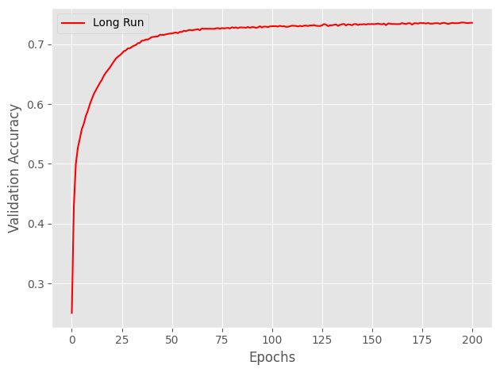

```python
# tune and run model with five layers
vals = { 'n_hidden':30,
         'C':0.1, 'epochs':200, 'eta':0.0001,
         'alpha':0.001, 'decrease_const':1, 'minibatches':50,
         'shuffle':True,'random_state':1 }

nn_long_sigmoid = TLPFiveLayer(**vals)

%time nn_long_sigmoid.fit(X_train, y_train, print_progress=1, XY_test=(X_test,y_test))
evals4=nn_long_sigmoid.val_score_
print_result(nn_long_sigmoid,X_train,y_train,X_test,y_test,title="Long Run",color="red")
```

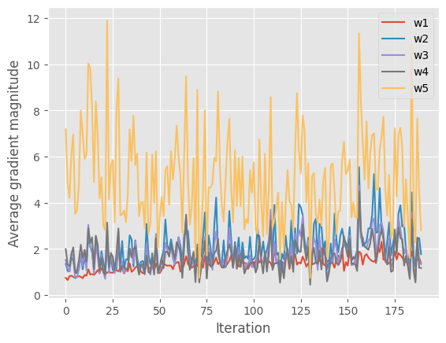

```python
# print average gradient magnitude across 5 layers
ax = plt.subplot(1,1,1)
plt.plot(np.abs(nn_long_sigmoid.grad_w1_[10:]), label='w1')
plt.plot(np.abs(nn_long_sigmoid.grad_w2_[10:]), label='w2')
plt.plot(np.abs(nn_long_sigmoid.grad_w3_[10:]), label='w3')
plt.plot(np.abs(nn_long_sigmoid.grad_w4_[10:]), label='w4')
plt.plot(np.abs(nn_long_sigmoid.grad_w5_[10:]), label='w5')
plt.legend()
plt.ylabel('Average gradient magnitude')
plt.xlabel('Iteration')
plt.show()
```

[2 points] Implement an adaptive learning technique that was discussed in lecture and use it on the five layer network (choose either RMSProp or AdaDelta). Discuss which adaptive method you chose. Compare the performance of your five layer model with and without the adaptive learning strategy. Do not use AdaM for the adaptive learning technique as it is part of the exceptional work.

```python
class TLPRMSProp(TLPFiveLayer):
    def fit(self, X, y, print_progress=False, XY_test=None):
        """ Learn weights from training data. With mini-batch"""
        X_data, y_data = X.copy(), y.copy()
        Y_enc = self._encode_labels(y)

        # init weights and setup matrices
        self.n_features_ = X_data.shape[1]
        self.n_output_ = Y_enc.shape[0]
        self.W1, self.W2, self.W3, self.W4, self.W5, self.b1, self.b2, self.b3, self.b4, self.b5 = self._initialize_weights()

        # adaptive V for entire gradient
        V1_prev = np.zeros(self.W1.shape) # for adaptive
        V2_prev = np.zeros(self.W2.shape) # for adaptive
        V3_prev = np.zeros(self.W3.shape) # for adaptive
        V4_prev = np.zeros(self.W4.shape) # for adaptive
        V5_prev = np.zeros(self.W5.shape) # for adaptive

        self.cost_ = []
        self.score_ = []
        # get starting acc
        self.score_.append(accuracy_score(y_data,self.predict(X_data)))
        # keep track of validation, if given
        if XY_test is not None:
            X_test = XY_test[0].copy()
            y_test = XY_test[1].copy()
            self.val_score_ = []
            self.val_score_.append(accuracy_score(y_test,self.predict(X_test)))
            self.val_cost_ = []

        for i in range(self.epochs):

            # adaptive learning rate
            # decrease at certain epochs
            eta = self.eta * self.decrease_const**(np.floor(i/self.decrease_iter))

            if print_progress>0 and (i+1)%print_progress==0:
                sys.stderr.write('\rEpoch: %d/%d' % (i+1, self.epochs))
                sys.stderr.flush()

            if self.shuffle:
                idx_shuffle = np.random.permutation(y_data.shape[0])
                X_data, Y_enc, y_data = X_data[idx_shuffle], Y_enc[:, idx_shuffle], y_data[idx_shuffle]

            mini = np.array_split(range(y_data.shape[0]), self.minibatches)
            mini_cost = []
            for idx in mini:

                # feedforward
                A1, Z1, A2, Z2, A3, Z3, A4, Z4, A5, Z5, A6 = self._feedforward(X_data[idx],
                                                       self.W1,
                                                       self.W2,
                                                       self.W3,
                                                       self.W4,
                                                       self.W5,
                                                       self.b1,
                                                       self.b2,
                                                       self.b3,
                                                       self.b4,
                                                       self.b5
                                                      )

                cost = self._cost(A6, Y_enc[:, idx], self.W1, self.W2, self.W3, self.W4, self.W5)
                mini_cost.append(cost) # this appends cost of mini-batch only

                # compute gradient via backpropagation
                gradW1, gradW2, gradW3, gradW4, gradW5, gradb1, gradb2, gradb3, gradb4, gradb5 = self._get_gradient(A1=A1, A2=A2, A3=A3, A4=A4, A5=A5, A6=A6,
                                                                                                                 Z1=Z1, Z2=Z2, Z3=Z3, Z4=Z4, Z5=Z5,
                                                                                                                 Y_enc=Y_enc[:, idx],
                                                                                                                 W1=self.W1, W2=self.W2, W3=self.W3, W4=self.W4, W5=self.W5
                                                                                                                )

                # adaptation calculations:
                # these are the calculated square gradients for each weight matrix
                G1 = gradW1*gradW1
                G2 = gradW2*gradW2
                G3 = gradW3*gradW3
                G4 = gradW4*gradW4
                G5 = gradW5*gradW5

                # these are the updated moving averages for these squared gradients
                # the alpha parameter controls the decay rate of this moving average
                # the moving average is average of the data across subsets
                # the moving average uses a "window" to know how many data points to include in each average
                # the moving average starts one the current data point and takes the previous data points to use in the average
                # EX: test_data = [1, 2, 3, 4] & window size 2
                # (1+2)/2 = 1.5, (2+3)/2 = 2.5, (3+4)/2 = 3.5
                # the moving average is used in Machine learning to smooth out fluctuations in the gradient & show larger trends in the gradient changes
                V1 = self.alpha*V1_prev + (1 - self.alpha)*G1
                V2 = self.alpha*V2_prev + (1 - self.alpha)*G2
                V3 = self.alpha*V3_prev + (1 - self.alpha)*G3
                V4 = self.alpha*V4_prev + (1 - self.alpha)*G4
                V5 = self.alpha*V5_prev + (1 - self.alpha)*G5

                # RMSProp
                rho_W1, rho_W2, rho_W3, rho_W4, rho_W5 = eta/np.sqrt(V1+1e-7) * gradW1, eta/np.sqrt(V2+1e-7) * gradW2, eta/np.sqrt(V3+1e-7) * gradW3, eta/np.sqrt(V4+1e-7) * gradW4, eta/np.sqrt(V5+1e-7) * gradW5
                self.W1 -= rho_W1
                self.W2 -= rho_W2
                self.W3 -= rho_W3
                self.W4 -= rho_W4
                self.W5 -= rho_W5
                self.b1 -= eta * gradb1
                self.b2 -= eta * gradb2
                self.b3 -= eta * gradb3
                self.b4 -= eta * gradb4
                self.b5 -= eta * gradb5

                # update previous parameters for RMSProp
                V1_prev, V2_prev, V3_prev, V4_prev, V5_prev = V1, V2, V3, V4, V5

            self.cost_.append(np.mean(mini_cost))
            self.score_.append(accuracy_score(y_data,self.predict(X_data)))
            if XY_test is not None:
                yhat = self.predict(X_test)
                self.val_score_.append(accuracy_score(y_test,yhat))

        return self
```

```
Epoch: 200/200
```

```
CPU times: user 3min 7s, sys: 1min 51s, total: 4min 58s
Wall time: 3min 2s
=================
Long Run :
Resubstitution acc: 0.7237425654072266
{0, 1, 2, 3}
Validation acc: 0.7223597359735974
{0, 1, 2, 3}
```

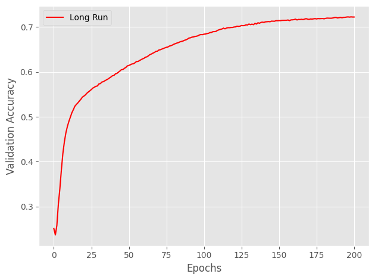

```python
# tune and run the model with RMSProp
vals = { 'n_hidden':30,
         'C':0.1, 'epochs':200, 'eta':0.0001,
         'alpha':0.001, 'decrease_const': 1, 'minibatches':50,
         'shuffle':True,'random_state':1 }

nn_long_sigmoid = TLPRMSProp(**vals)

%time nn_long_sigmoid.fit(X_train, y_train, print_progress=1, XY_test=(X_test,y_test))
evals5=nn_long_sigmoid.val_score_
print_result(nn_long_sigmoid,X_train,y_train,X_test,y_test,title="Long Run",color="red")
```

```python
# compare the standard five layer score with the RMSProp five layer score
#===================================================
# Enter your code below
from sklearn.model_selection import cross_val_score
print('Mean Score for Model 4, standard 5-layer:', np.mean(evals4))
print('Mean Score for Model 5, with RMSProp:', np.mean(evals5))


# t = 2.26 / np.sqrt(10)
t= 1.96

# model 4 and 5
e_list = [(1-evals4[i]) - (1-evals5[i])for i in range(len(evals4))]
# e = (1-evals1) - (1-evals2)
stdtot = np.std(e_list)
dbar = np.mean(e_list)
print('Interval for Model 4 and 5:', dbar-t*stdtot, dbar+t*stdtot)

#===================================================
```

```
Mean Score for Model 4, standard 5-layer: 0.7106009419349896
Mean Score for Model 5, with RMSProp: 0.649562624172865
Interval for Model 4 and 5: -0.1531541664029667 0.031077530878717764
```

We decided to choose the RMSProp implementation because RMSProp requires fewer hyperparameters than AdaDelta, making RMSProp easier to configure. As a reminder, the hyperparameters are the settings that govern the behavior of the model, and are set before the model is run.

RMSProp tracks a moving average of the gradients only, but AdaDelta maintains a moving average of both the gradients and weight updates. As a result, AdaDelta is more memory intensive than RMSProp.

Model 4's mean score is greater than model 5's mean score. Model 4 is the standard model and model 5 uses RMSProp. The confidence interval between model 4 and model 5 has a negative lower bound and a positive upper bound. The interval contains a 0 between the upper bound and lower bound range, so the null hypothesis cannot be rejected. This means that the statistical difference could be zero. Therefore, there is not enough evidence to determine if there is a significant statistical difference between model 4 and model 5. Any difference seen between the models mean scores might be due to random variation within the sample data.

## Exceptional Work

5000 level student: You have free reign to provide additional analyses. One idea (required for 7000 level students): Implement adaptive momentum (AdaM) in the five layer neural network and quantify the performance compared to other methods.

```python
# implement the adaptive momentum (AdaM) in the five layer neural network
# AdaM uses the adaptive learning of RMSProp with added momentum for an even better convergence rate
# quantify the performance compared to other methods
class TLPAdaM(TLPFiveLayer):
    def fit(self, X, y, print_progress=False, XY_test=None):
        """ Learn weights from training data. With mini-batch"""
        X_data, y_data = X.copy(), y.copy()
        Y_enc = self._encode_labels(y)

        # init weights and setup matrices
        self.n_features_ = X_data.shape[1]
        self.n_output_ = Y_enc.shape[0]
        self.W1, self.W2, self.W3, self.W4, self.W5, self.b1, self.b2, self.b3, self.b4, self.b5 = self._initialize_weights()

        beta1 = 0.9
        beta2 = 0.999
        k = 0

        # adaptive M for entire gradient
        M1_prev = np.zeros(self.W1.shape) # for adaptive
        M2_prev = np.zeros(self.W2.shape) # for adaptive
        M3_prev = np.zeros(self.W3.shape) # for adaptive
        M4_prev = np.zeros(self.W4.shape) # for adaptive
        M5_prev = np.zeros(self.W5.shape) # for adaptive

        # adaptive V for entire gradient
        V1_prev = np.zeros(self.W1.shape) # for adaptive
        V2_prev = np.zeros(self.W2.shape) # for adaptive
        V3_prev = np.zeros(self.W3.shape) # for adaptive
        V4_prev = np.zeros(self.W4.shape) # for adaptive
        V5_prev = np.zeros(self.W5.shape) # for adaptive

        self.cost_ = []
        self.score_ = []
        # get starting acc
        self.score_.append(accuracy_score(y_data,self.predict(X_data)))
        # keep track of validation, if given
        if XY_test is not None:
            X_test = XY_test[0].copy()
            y_test = XY_test[1].copy()
            self.val_score_ = []
            self.val_score_.append(accuracy_score(y_test,self.predict(X_test)))
            self.val_cost_ = []

        for i in range(self.epochs):

            # adaptive learning rate
            # decrease at certain epochs
            eta = self.eta * self.decrease_const**(np.floor(i/self.decrease_iter))

            if print_progress>0 and (i+1)%print_progress==0:
                sys.stderr.write('\rEpoch: %d/%d' % (i+1, self.epochs))
                sys.stderr.flush()

            if self.shuffle:
                idx_shuffle = np.random.permutation(y_data.shape[0])
                X_data, Y_enc, y_data = X_data[idx_shuffle], Y_enc[:, idx_shuffle], y_data[idx_shuffle]

            mini = np.array_split(range(y_data.shape[0]), self.minibatches)
            mini_cost = []
            for idx in mini:

                # feedforward
                A1, Z1, A2, Z2, A3, Z3, A4, Z4, A5, Z5, A6 = self._feedforward(X_data[idx],
                                                       self.W1,
                                                       self.W2,
                                                       self.W3,
                                                       self.W4,
                                                       self.W5,
                                                       self.b1,
                                                       self.b2,
                                                       self.b3,
                                                       self.b4,
                                                       self.b5
                                                      )

                cost = self._cost(A6, Y_enc[:, idx], self.W1, self.W2, self.W3, self.W4, self.W5)
                mini_cost.append(cost) # this appends cost of mini-batch only

                # compute gradient via backpropagation
                gradW1, gradW2, gradW3, gradW4, gradW5, gradb1, gradb2, gradb3, gradb4, gradb5 = self._get_gradient(A1=A1, A2=A2, A3=A3, A4=A4, A5=A5, A6=A6,
                                                                                                                 Z1=Z1, Z2=Z2, Z3=Z3, Z4=Z4, Z5=Z5,
                                                                                                                 Y_enc=Y_enc[:, idx],
                                                                                                                 W1=self.W1, W2=self.W2, W3=self.W3, W4=self.W4, W5=self.W5
                                                                                                                )

                # adaptation calculations:
                k += 1

                G1 = gradW1*gradW1
                G2 = gradW2*gradW2
                G3 = gradW3*gradW3
                G4 = gradW4*gradW4
                G5 = gradW5*gradW5

                M1 = beta1*M1_prev + (1 + beta1)*gradW1
                M2 = beta1*M2_prev + (1 + beta1)*gradW2
                M3 = beta1*M3_prev + (1 + beta1)*gradW3
                M4 = beta1*M4_prev + (1 + beta1)*gradW4
                M5 = beta1*M5_prev + (1 + beta1)*gradW5

                V1 = beta2*V1_prev + (1 - beta2)*G1
                V2 = beta2*V2_prev + (1 - beta2)*G2
                V3 = beta2*V3_prev + (1 - beta2)*G3
                V4 = beta2*V4_prev + (1 - beta2)*G4
                V5 = beta2*V5_prev + (1 - beta2)*G5

                M1_hat = M1 / (1 - beta1**k)
                M2_hat = M2 / (1 - beta1**k)
                M3_hat = M3 / (1 - beta1**k)
                M4_hat = M4 / (1 - beta1**k)
                M5_hat = M5 / (1 - beta1**k)

                V1_hat = V1 / (1 - beta2**k)
                V2_hat = V2 / (1 - beta2**k)
                V3_hat = V3 / (1 - beta2**k)
                V4_hat = V4 / (1 - beta2**k)
                V5_hat = V5 / (1 - beta2**k)

                # momentum and adagrad
                rho_W1, rho_W2, rho_W3, rho_W4, rho_W5 = eta * M1_hat/np.sqrt(V1_hat+1e-7), eta * M2_hat/np.sqrt(V2_hat+1e-7), eta * M3_hat/np.sqrt(V3_hat+1e-7), eta * M4_hat/np.sqrt(V4_hat+1e-7), eta * M5_hat/np.sqrt(V5_hat+1e-7)
                self.W1 -= rho_W1
                self.W2 -= rho_W2
                self.W3 -= rho_W3
                self.W4 -= rho_W4
                self.W5 -= rho_W5
                self.b1 -= eta * gradb1
                self.b2 -= eta * gradb2
                self.b3 -= eta * gradb3
                self.b4 -= eta * gradb4
                self.b5 -= eta * gradb5

                # update previous parameters for M and V
                M1_prev, M2_prev, M3_prev, M4_prev, M5_prev = M1, M2, M3, M4, M5
                V1_prev, V2_prev, V3_prev, V4_prev, V5_prev = V1, V2, V3, V4, V5

            self.cost_.append(np.mean(mini_cost))
            self.score_.append(accuracy_score(y_data,self.predict(X_data)))
            if XY_test is not None:
                yhat = self.predict(X_test)
                self.val_score_.append(accuracy_score(y_test,yhat))

        return self
```

```
Epoch: 200/200
```

```
CPU times: user 3min 7s, sys: 1min 51s, total: 4min 59s
Wall time: 3min 2s
=================
Long Run :
Resubstitution acc: 0.7467425310276068
{0, 1, 2, 3}
Validation acc: 0.7387238723872387
{0, 1, 2, 3}
```

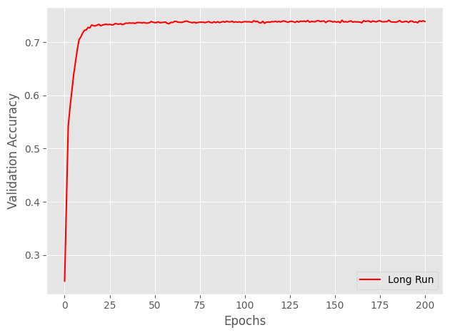

```python
# tune and run model
vals = { 'n_hidden':30,
         'C':0.1, 'epochs':200, 'eta':0.0001,
         'alpha':0.001, 'decrease_const':1, 'minibatches':50,
         'shuffle':True,'random_state':1 }

nn_long_sigmoid = TLPAdaM(**vals)

%time nn_long_sigmoid.fit(X_train, y_train, print_progress=1, XY_test=(X_test,y_test))
evals6=nn_long_sigmoid.val_score_
print_result(nn_long_sigmoid,X_train,y_train,X_test,y_test,title="Long Run",color="red")
```

```python
# quantify AdaM compared to standard 5 layer & RMSProp
#===================================================
# Enter your code below
from sklearn.model_selection import cross_val_score
print('Mean Score for Model 4, standard 5-layer:', np.mean(evals4))
print('Mean Score for Model 5, with RMSProp:', np.mean(evals5))
print('Mean Score for Model 6, with ADAM:', np.mean(evals6))

#t = 2.26 / np.sqrt(200)
t= 1.96

# model 4 and 5
e_list = [(1-evals4[i]) - (1-evals5[i])for i in range(len(evals4))]
# e = (1-evals1) - (1-evals2)
stdtot = np.std(e_list)
dbar = np.mean(e_list)
print('Interval for Model 4 and 5:', dbar-t*stdtot, dbar+t*stdtot)

# # model 5 and 6
e_list = [(1-evals5[i]) - (1-evals6[i])for i in range(len(evals4))]
# e = (1-evals1) - (1-evals2)
stdtot = np.std(e_list)
dbar = np.mean(e_list)
print('Interval for Model 5 and 6:', dbar-t*stdtot, dbar+t*stdtot)

# # model 6 and 4
e_list = [(1-evals6[i]) - (1-evals4[i])for i in range(len(evals4))]
# e = (1-evals1) - (1-evals2)
stdtot = np.std(e_list)
dbar = np.mean(e_list)
print('Interval for Model 6 and 4:', dbar-t*stdtot, dbar+t*stdtot)

#===================================================
```

```
Mean Score for Model 4, standard 5-layer: 0.7106009419349896
Mean Score for Model 5, with RMSProp: 0.649562624172865
Mean Score for Model 6, with ADAM: 0.7291529837063309
Interval for Model 4 and 5: -0.1531541664029667 0.031077530878717764
Interval for Model 5 and 6: -0.05122948572721338 0.21041020479414496
Interval for Model 6 and 4: -0.06802445466105268 0.030920371118370055
```

Model 6 (Adam) has a larger mean score than all other models. This larger mean score may be because Adam pairs momentum with adaptive learning. Momentum helps accelerate gradients in the right direction, leading to faster convergence, while adaptive learning rates adjust the step size for each weight, which can improve the rate of convergence and stability of the learning process. The standard method does not use adaptive learning, and RMSProp uses adaptive learning without factoring in momentum. This difference in method means that Adam may have advantages over model 4 (standard) and Model 5 (RMSProp).

However, the confidence intervals between these models all include 0 in their range because every confidence interval is going from a negative lower bound to a positive upper bound. Since the confidence scores all include 0, the null hypothesis cannot be rejected. There is no way to tell if these models have signficant statistical differences, as their statistical differences could be 0. Any differences between the mean scores could come from random variation in the data.